# Lineage Analysis of CRISPR and shRNA Screens

Sally Claridge

12 September 2018

Analysis of the Broad’s Avana CRISPR (Broad Institute Cancer Dependency Map 2018, Meyers et al. 2017) and the Broad and Dana-Farber Cancer Institite’s Achilles shRNA (MacFarland et al. 2018, Data Science 2018).

The Avana screen produced results using [CERES](https://depmap.org/ceres/) (Meyers et al. 2017) ([GitHub](https://github.com/cancerdatasci/ceres)), which generates gene dependency scores from sgRNA depletion scores from gene essentiality screens and eliminates bias arising from the effect of copy number variation on Cas9 DNA cleavage. The lower the CERES score, the higher the likelihood that the gene is essential in the associated cell line. Scores are scaled per cell line such that a score of 0 is the median effect of nonessential genes and -1 is the median effect of common core essential genes.

In a previous version of the shRNA screen, DEMETER ([GitHub](https://github.com/cancerdatasci/demeter)) was used to compute a dependency score for each gene by using the depletion values from each shRNA to infer the effect of target knockdown (on-target) and of expressing a given miRNA seed (off-target) in each cell line. More negative values indicate increased dependency, while more positive values indicate lower dependency. Zero represents the avergae dependency across all cell lines.

In the new data release, [DEMETER2](https://depmap.org/R2-D2/) ([GitHub repository](https://github.com/cancerdatasci/demeter2)), developed by McFarland et al. (2018) was used to analyze the Achilles screen. DEMETER2 expands on DEMETER by including parameters for cell-line-specific screen effects and noisy data, correcting for global differences in shRNA levels across cell lines, pooling data acorss cell lines via hierarchical modeling, and using Bayesian inference to compute uncertainty estimates. Now, a score of zero represents no dependency.

All annotation files (copy number, mutation status, and gene expression) (Consortium and Consortium 2015, Barretina et al. 2012) were downloaded from the [DepMap Data Portal](https://depmap.org/portal/download/).

# 1 Set up

Load libraries.

```r
library(NMF)
library(ggpubr)
library(ggsignif)
library(rowr)
library(data.table)
library(CePa)
library(plyr)
library(tidyverse)
library(magrittr)
library(matrixStats)
library(parallel)
library(kableExtra)
library(gridExtra)
library(broom)
library(glmnet)
library(devtools)
library(reshape2)
library(caret)
library(bsselectR)
library(ComplexHeatmap)
library(circlize)
```

# 2 Functions

## 2.1 Significance thresholding

```r
adj_signif <- function(df) {
  # Takes df from compare_means and creates a signif code column for adjusted p-vals
  df$p.signif <- ifelse(df$p.signif == "ns", NA, df$p.signif)
  df$p.signif.adj <- ifelse(df$p.adj <= 0.0001, "****",
                     ifelse(df$p.adj <= 0.001, "***",
                     ifelse(df$p.adj <= 0.01, "**",
                     ifelse(df$p.adj <= 0.05, "*", NA))))
  df$p.short <- formatC(df$p, format = "g", digits =  2)
  df$p.adj.short <- formatC(df$p.adj, format = "g", digits =  2)

  return(df)
}
```

## 2.2 Make CRISPR grobs

```r
makeCRISPRgrob <- function(g) {

  gene <- filter(crispr_data, Hugo_Symbol == g)

  # Mutation status
  crispr_color <- as.character(gene$Color)
  names(crispr_color) <- gene$Mutation_Status
  sig <- filter(crispr_signif, Hugo_Symbol == g)
  plot_mut <- ggplot(data = gene, aes(x = Mutation_Status, y = Score, color = Mutation_Status)) +
    geom_boxplot(outlier.shape = NA) +
    geom_jitter(alpha = 0.3, size = 0.7, position = position_jitter(w = 0.05)) +
    scale_color_manual(values = crispr_color) +
    geom_hline(yintercept = 0, linetype = 2, lwd = 0.3) +
    theme_light() +
    theme(legend.position = "none") +
    labs(x = paste0(g, " Mutation Status"), y = "CERES Score",
         title = "Mutation Status",
         subtitle = paste0("Wilcoxon test:\n- BH-corrected p-value: ", sig$p.adj.short, "\n- Uncorrected p-value: ", sig$p.short, "\nMutant lines harbor deleterious mutations."))

  # Copy number
  lo_cn <- range(gene$Copy_Number[!is.na(gene$Copy_Number)])[1]
  hi_cn <- range(gene$Copy_Number[!is.na(gene$Copy_Number)])[2]
  mid_cn <- (hi_cn - lo_cn) / 2
  plot_cn <- ggplot(data = gene, aes(x = Copy_Number, y = Score, color = Mutation_Status)) +
    geom_point(size = 0.5, alpha = 0.5) +
    geom_smooth(method = "lm", size = 0.5) +
    geom_hline(yintercept = 0, linetype = 2, lwd = 0.3) +
    scale_color_manual(values = crispr_color) +
    stat_cor(method = "pearson", show.legend = FALSE, label.x = c((lo_cn + mid_cn) / 2, (hi_cn - mid_cn) / 2 + mid_cn), label.y = max(gene$Score)) +
    theme(legend.position = "none") +
    labs(y = "CERES Score", color = "Mutation Status",
         x = paste0(g, " Theoretical Copy number"), title = "Copy Number",
         subtitle = "r: Pearson correlation coeffcient")

  # Gene expression
  lo_ge <- range(gene$RPKM_log2[!is.na(gene$RPKM_log2)])[1]
  hi_ge <- range(gene$RPKM_log2[!is.na(gene$RPKM_log2)])[2]
  mid_ge <- (hi_ge - lo_ge) / 2
  plot_ge <- ggplot(data = gene, aes(x = RPKM_log2, y = Score, color = Mutation_Status)) +
    geom_point(size = 0.5, alpha = 0.5) +
    geom_smooth(method = "lm", size = 0.5) +
    geom_hline(yintercept = 0, linetype = 2, lwd = 0.3) +
    scale_color_manual(values = crispr_color) +
    stat_cor(method = "pearson", show.legend = FALSE, label.x = c((lo_ge + mid_ge) / 2, (hi_ge - mid_ge) / 2 + mid_ge), label.y = max(gene$Score)) +
    theme(legend.position = "none") +
    labs(y = "CERES Score", color = "Mutation Status",
         x = paste0(g, " Gene Expression [log2(RPKM)]"),
         title = "Gene Expression",
         subtitle = "r: Pearson correlation coeffcient")

  # Cell line lineage
  plot_tissue <- ggplot(data = gene, aes(x = primary_tissue, y = Score, color = Mutation_Status)) +
    geom_point(alpha = 0.5) +
    scale_color_manual(values = crispr_color) +
    geom_hline(yintercept = 0, linetype = 2, lwd = 0.3) +
    scale_y_continuous(sec.axis = sec_axis(~ .)) +
    coord_flip() +
    theme(legend.position = "none") +
    labs(y = "CERES Score", x = "Primary Tissue",
         color = "Mutation Status", title = g)

  # Arrange plots
  plot <- ggarrange(ggarrange(plot_tissue, nrow = 1, labels = c("A")),
                    ggarrange(plot_mut, plot_cn, plot_ge, nrow = 3,
                              labels = c("B", "C", "D"), heights = c(2, 3, 3)),
                    font.label = list(size = 30, face = "bold"),
                    nrow = 1, ncol = 2, widths = c(3, 2))
  return(plot)
}
```

## 2.3 Make lineage plot

```r
makeCRISPRlinplot <- function(g) {
  sig <- filter(crispr_signif_lineage, Hugo_Symbol == g)
  if(nrow(sig) == 0) {
    return(NULL)
  }
  else {
    gene <- filter(crispr_data, Hugo_Symbol == g)
    gene <- merge(gene, sig, by = c("Hugo_Symbol", "group_general_lineage_name"))
    gene <- mutate(gene, group_general_lineage_name = reorder(group_general_lineage_name, p, mean))
    crispr_color <- as.character(gene$Color)
    names(crispr_color) <- gene$Mutation_Status
    score_range <- abs(range(gene$Score)[2] - range(gene$Score)[1])
    round_accuracy <- ifelse(score_range <= 2, 0.25,
                             ifelse(score_range <= 3, 0.5, 1.0))

    plot <- ggplot(data = gene, aes(x = group_general_lineage_name, y = Score)) +
      geom_point(alpha = 0.5, mapping = aes(color = Mutation_Status)) +
      scale_color_manual(values = crispr_color) +
      coord_cartesian(y = c(min(gene$Score), round_any(x = max(gene$Score), accuracy = round_accuracy, f = ceiling))) +
      geom_signif(data = gene, mapping = aes(xmin = group_general_lineage_name, xmax = group_general_lineage_name, annotations = paste(p.short, "\n", p.adj.short), y_position = max(gene$Score)), manual = TRUE, tip_length   = 0, size = 0, textsize = 3) +
      theme(legend.position = "top", axis.text.x = element_text(angle = 70, hjust = 1, size = 10)) +
      labs(y = "CERES Score",
           x = "Lineage",
           color = "Mutation Status",
           title = paste0(g, ": CERES score by cell line lineage"),
           subtitle = "Lineages sorted by increasing p-value; labels indicate unadjusted p-value / BH-corrected p-value.\nMutant lines harbor deleterious mutations.")
    return(plot)
  }
}
```

## 2.4 Make tissue plot

```r
makeCRISPRtissueplot <- function(g) {
  sig <- filter(crispr_signif_tissue, Hugo_Symbol == g)
  if(nrow(sig) == 0) {
    return(NULL)
  }
  else {
    gene <- filter(crispr_data, Hugo_Symbol == g)
    gene <- merge(gene, sig, by = c("Hugo_Symbol", "primary_tissue"))
    gene <- mutate(gene, primary_tissue = reorder(primary_tissue, p, mean))
    crispr_color <- as.character(gene$Color)
    names(crispr_color) <- gene$Mutation_Status
    score_range <- abs(range(gene$Score)[2] - range(gene$Score)[1])
    round_accuracy <- ifelse(score_range <= 2, 0.25,
                             ifelse(score_range <= 3, 0.5, 1.0))

    plot <- ggplot(data = gene, aes(x = primary_tissue, y = Score)) +
      geom_point(alpha = 0.5, mapping = aes(color = Mutation_Status)) +
      scale_color_manual(values = crispr_color) +
      coord_cartesian(y = c(min(gene$Score), round_any(x = max(gene$Score), accuracy = round_accuracy, f = ceiling))) +
      geom_signif(data = gene, mapping = aes(xmin = primary_tissue, xmax = primary_tissue, annotations = paste(p.short, "\n", p.adj.short), y_position = max(gene$Score)), manual = TRUE, tip_length   = 0, size = 0, textsize = 3) +
      theme(legend.position = "top", axis.text.x = element_text(angle = 70, hjust = 1, size = 10)) +
      labs(y = "CERES Score",
           x = "Primary Tissue",
           color = "Mutation Status",
           title = paste0(g, ": CERES score by cell line primary tissue"),
           subtitle = "Primary tissues sorted by increasing p-value; labels indicate unadjusted p-value / BH-corrected p-value.\nMutant lines harbor deleterious mutations.")
    return(plot)
  }
}
```

# 3 Data management

## 3.1 D. Charytonowicz cell line converter

This comprehensive cancer cell line information curated by Daniel Charytonowicz.

```r
ccl_converter <- read.delim("./data_munging/cell_line_database_v1_20180911.tsv", row.names = 1, sep = "\t", header = TRUE)
```

## 3.2 DepMap cell line metadata

```r
ccl_info <- read.delim("./data_munging/DepMap-2018q3-celllines.csv", sep = ",", header = TRUE, na.strings = c("", NA))
ccl_info$Primary.Disease <- gsub("\\\\", "", ccl_info$Primary.Disease)
ccl_info$Primary.Disease <- gsub("Ewings", "Ewing's", ccl_info$Primary.Disease)

# From figshare
crispr_meta <- read.delim("./data_munging/sample_info_18Q3_crispr.csv", sep = ",", header = TRUE, na.strings = c("", NA))
colnames(crispr_meta)[7] <- "CCLE_Name"
```

## 3.3 CGC gene list

Select genes from the Cancer Gene Census (CGC). The list was pulled from the [International Cancer Genome Consortium (ICGC) data portal](https://dcc.icgc.org/search/g?filters=%7B%22gene%22:%7B%22curatedSetId%22:%7B%22is%22:%5B%22GS1%22%5D%7D%7D%7D) (Advaced Search > Genes > Curated Gene Set > Cancer Gene Census).

```r
cgc <- data_frame("Hugo_Symbol" = read.delim("./data_munging/gene-ids-for-set-Cancer Gene Census.tsv", header = FALSE, sep = "\t")[, 2])
```

## 3.4 CCLE MAF file

For mutation calling, get paired gene name and cell line fields in a data frame. For this analysis, we don’t care about how many mutations there are per gene or what type of mutations there are, so I didn’t save more information. I took unique gene-cell line combinations since we only cared about mutation presence/absence. Add a `Mutation_Status` column denoting all entries in MAF files as mutations present in the associated cell lines.

```r
maf_raw <- read.delim("./data_munging/CCLE_DepMap_18q3_maf_20180718.txt.gz", header = TRUE, sep = "\t")
# Filter for cell lines in CRISPR screen
maf_raw <- filter(maf_raw, Broad_ID %in% unique(crispr_meta$Broad_ID))

# Select columns
maf_df <- subset(maf_raw, select = c("Hugo_Symbol", "Tumor_Sample_Barcode", "Broad_ID", "Variant_Classification", "isDeleterious", "Reference_Allele"))
colnames(maf_df)[colnames(maf_df) == "Tumor_Sample_Barcode"] <- "CCLE_Name"
maf_df$Var_Length <- nchar(as.character(maf_df$Reference_Allele))

# Add Mutation_Status column
maf_df$Mutation_Status_Deleterious <- ifelse(maf_df$isDeleterious == TRUE, "Mutant", "Other")
maf_df$Mutation_Status_Nonsilent <- ifelse(maf_df$Variant_Classification == "Silent", "Other", "Mutant")
maf_df$Mutation_Status_DeleteriousMissense <- ifelse(maf_df$isDeleterious == TRUE | maf_df$Variant_Classification == "Missense_Mutation", "Mutant", "Other")
maf_df <- unique(subset(maf_df, select = c("Hugo_Symbol", "CCLE_Name", "Broad_ID", "Mutation_Status_Deleterious", "Mutation_Status_Nonsilent", "Mutation_Status_DeleteriousMissense", "Var_Length")))

# Whole MAF summary table
maf_summ <- maf_raw[, c("Variant_Classification", "isDeleterious")] %>% group_by(Variant_Classification, isDeleterious) %>% tally()
maf_summ$Percent <- format(round(maf_summ$n / sum(maf_summ$n) * 100, 4), nsmall = 2)
maf_summ$isDeleterious <- ifelse(maf_summ$isDeleterious == "TRUE", "Yes", "No")

knitr::kable(maf_summ, caption = "Distribution of variant classifications in the MAF file") %>% kable_styling(bootstrap_options = c("striped", "hover", "condensed", "responsive"))
```

Distribution of variant classifications in the MAF file

| Variant_Classification | isDeleterious | n | Percent |
| --- | --- | --- | --- |
| 3’UTR | No | 1 | 0.0003 |
| 3’UTR | Yes | 30 | 0.0084 |
| 5’Flank | No | 8 | 0.0022 |
| 5’Flank | Yes | 34 | 0.0095 |
| 5’UTR | No | 2 | 0.0006 |
| 5’UTR | Yes | 15 | 0.0042 |
| De_novo_Start_OutOfFrame | Yes | 2006 | 0.5595 |
| Frame_Shift_Del | Yes | 12441 | 3.4698 |
| Frame_Shift_Ins | Yes | 9215 | 2.5701 |
| IGR | No | 6 | 0.0017 |
| IGR | Yes | 44 | 0.0123 |
| In_Frame_Del | No | 1747 | 0.4872 |
| In_Frame_Ins | No | 442 | 0.1233 |
| Intron | No | 9 | 0.0025 |
| Intron | Yes | 187 | 0.0522 |
| Missense_Mutation | No | 211359 | 58.9484 |
| Nonsense_Mutation | Yes | 12711 | 3.5451 |
| Nonstop_Mutation | Yes | 335 | 0.0934 |
| Silent | No | 94225 | 26.2795 |
| Splice_Site | Yes | 13180 | 3.6759 |
| Start_Codon_Del | Yes | 25 | 0.0070 |
| Start_Codon_Ins | Yes | 33 | 0.0092 |
| Start_Codon_SNP | No | 402 | 0.1121 |
| Stop_Codon_Del | No | 1 | 0.0003 |
| Stop_Codon_Del | Yes | 52 | 0.0145 |
| Stop_Codon_Ins | Yes | 39 | 0.0109 |

```r
max(nchar(as.character(maf_raw$Reference_Allele)))
```

```
## [1] 6494
```

```r
maf_raw %>% group_by(Variant_Type, isTCGAhotspot) %>% tally()
```

```
## # A tibble: 9 x 3
## # Groups:   Variant_Type [?]
##   Variant_Type isTCGAhotspot      n
##   <fct>        <lgl>          <int>
## 1 DEL          FALSE          13940
## 2 DEL          TRUE            1453
## 3 DNP          FALSE           2411
## 4 DNP          TRUE              36
## 5 INS          FALSE          10000
## 6 INS          TRUE             364
## 7 SNP          FALSE         321337
## 8 SNP          TRUE            8978
## 9 TNP          FALSE             30
```

```r
test <- filter(maf_raw, Hugo_Symbol == "KRAS")
test %>% group_by(isDeleterious) %>% tally()
```

```
## # A tibble: 2 x 2
##   isDeleterious     n
##   <lgl>         <int>
## 1 FALSE            95
## 2 TRUE              2
```

## 3.5 CCLE copy number file

```r
cn <- read.delim("./data_munging/public_18Q3_gene_cn.csv.gz", sep = ",", check.names = FALSE, header = TRUE)

# Convert log2 ratios (log2(CN/2)) to CN
cn[2:ncol(cn)] <- lapply(cn[2:ncol(cn)], function(x) 2 * (2 ^ x))

# Remove Entrez gene IDs from colnames
colnames(cn) <- gsub(" .*", "", colnames(cn))
colnames(cn)[1] <- "Broad_ID"

# Melt
cn_melt <- melt(data = cn, id.vars = "Broad_ID", measure.vars = colnames(cn[2:ncol(cn)]), variable.name = "Hugo_Symbol", value.name = "Copy_Number")

saveRDS(cn_melt, "./data_munging/rds/cn_melt_18Q3.rds", compress = "xz")
```

```r
cn_melt <- readRDS("./data_munging/rds/cn_melt_18Q3.rds")
```

## 3.6 CCLE gene expression file

Gene expression data (Reads Per Kilobase of transcript, per Million mapped reads, RPKM).

```r
ge <- read.delim("./../crispr_lineages_giant_files/CCLE_DepMap_18q3_RNAseq_RPKM_20180718.gct.gz", skip = 2, header = TRUE, sep = "\t", check.names = FALSE)

# Edit columns
ge$Name <- NULL
colnames(ge)[1] <- "Hugo_Symbol"

# Melt
ge_melt <- melt(data = ge, id.vars = "Hugo_Symbol", measure.vars = colnames(ge[2:ncol(ge)]), value.name = "RPKM")
## Split variable column
ge_melt <- with(ge_melt, cbind(Hugo_Symbol, colsplit(variable, pattern = " ", names = c("CCLE_Name", "Broad_ID")), RPKM))
## Remove parentheses around Broad IDs
ge_melt$Broad_ID <- gsub("\\(|\\)", "", ge_melt$Broad_ID)

saveRDS(ge_melt, "./../crispr_lineages_giant_files/ge_melt_18Q3.rds", compress = "xz")
```

```r
ge_melt <- readRDS("./../crispr_lineages_giant_files/ge_melt_18Q3.rds")
```

## 3.7 DepMap dependency probabilities

```r
dep <- read.delim("./data_munging/gene_dependency_18Q3.csv.gz", sep = ",", header  = TRUE, check.names = FALSE)
# Remove Entrez gene IDs from colnames
colnames(dep) <- gsub(" .*", "", colnames(dep))
```

## 3.8 Merge CRISPR data and annotations

The latest CRISPR CERES score data (18Q3, August 2018) was pulled from the [DepMap Data Portal](https://depmap.org/portal/download/) (Broad Institute Cancer Dependency Map 2018, Meyers et al. 2017).

```r
crispr <- read.delim("./data_munging/gene_effect_18Q3.csv.gz", sep = ",", header  = TRUE, check.names = FALSE)
# Remove Entrez gene IDs from colnames
colnames(crispr) <- gsub(" .*", "", colnames(crispr))
```

Merge annotation data:

```r
# Melt CRISPR dataset for merging
crispr_melt <- melt(crispr, id.vars = "Broad_ID", measure.vars = colnames(crispr)[2:ncol(crispr)], variable.name = "Hugo_Symbol", value.name = "Score")

# Melt dependency probabilities dataset for merging
dep_melt <- melt(dep, id.vars = "Broad_ID", measure.vars = colnames(dep)[2:ncol(dep)], variable.name = "Hugo_Symbol", value.name = "Dep_Prob")

# Merge dependency probabilities
crispr_melt <- merge(crispr_melt, dep_melt, by = c("Broad_ID", "Hugo_Symbol"), all.x = TRUE)

# Merge cell line metadata
crispr_melt <- merge(crispr_melt, ccl_info, by = "Broad_ID", all.x = TRUE)
crispr_melt <- merge(crispr_melt, crispr_meta, by = c("CCLE_Name", "Broad_ID"), all.x = TRUE)

# Merge mutation annotations
crispr_muts <- merge(crispr_melt, maf_df, by = c("Hugo_Symbol", "CCLE_Name", "Broad_ID"), all.x = TRUE)
crispr_muts$Hugo_Symbol <- factor(crispr_muts$Hugo_Symbol)
crispr_muts <- crispr_muts %>% mutate(Mutation_Status_Deleterious = if_else(is.na(Mutation_Status_Deleterious), "Other", Mutation_Status_Deleterious), Mutation_Status_DeleteriousMissense = if_else(is.na(Mutation_Status_DeleteriousMissense), "Other", Mutation_Status_DeleteriousMissense), Mutation_Status_Nonsilent = if_else(is.na(Mutation_Status_Nonsilent), "Other", Mutation_Status_Nonsilent))

# Summarize number of mutant and Other cell lines
crispr_muts_summ <- crispr_muts %>% group_by(Hugo_Symbol) %>%
  summarize(N_Deleterious_Other = sum(Mutation_Status_Deleterious == "Other"),
            N_Deleterious_Mutant = sum(Mutation_Status_Deleterious == "Mutant"),
            N_DeleteriousMissense_Other = sum(Mutation_Status_DeleteriousMissense == "Other"),
            N_DeleteriousMissense_Mutant = sum(Mutation_Status_DeleteriousMissense == "Mutant"),
            N_Nonsilent_Other = sum(Mutation_Status_Nonsilent == "Other"),
            N_Nonsilent_Mutant = sum(Mutation_Status_Nonsilent == "Mutant"))

# Merge test results back into full dataset, which restores information lost in the summarization
crispr_data <- merge(crispr_muts_summ, crispr_muts, by = "Hugo_Symbol")

# Add Color columns
crispr_data$Color_Deleterious <- ifelse(crispr_data$Mutation_Status_Deleterious == "Other", "cyan3", "darkorchid")
crispr_data$Color_Deleterious <- factor(crispr_data$Color_Deleterious)
crispr_data$Color_DeleteriousMissense <- ifelse(crispr_data$Mutation_Status_DeleteriousMissense == "Other", "cyan3", "darkorchid")
crispr_data$Color_DeleteriousMissense <- factor(crispr_data$Color_DeleteriousMissense)
crispr_data$Color_Nonsilent <- ifelse(crispr_data$Mutation_Status_Nonsilent == "Other", "cyan3", "darkorchid")
crispr_data$Color_Nonsilent <- factor(crispr_data$Color_Nonsilent)

# Cell line lineages
crispr_data <- merge(crispr_data, ccl_converter, by = c("CCLE_Name", "Broad_ID"), all.x = TRUE)
levels(crispr_data$lineage_name) <- sort(levels(crispr_data$lineage_name), decreasing = TRUE)

# Copy number
crispr_data <- merge(crispr_data, cn_melt, by = c("Hugo_Symbol", "Broad_ID"), all.x = TRUE)

# Gene expression (RPKM)
ge_filt <- filter(ge_melt, Hugo_Symbol %in% unique(crispr_data$Hugo_Symbol))
crispr_data <- merge(crispr_data, ge_filt, by = c("Hugo_Symbol", "Broad_ID", "CCLE_Name"), all.x = TRUE)
crispr_data$RPKM_log2 <- log2(crispr_data$RPKM + 0.0001)

saveRDS(crispr_data, "./../crispr_lineages_giant_files/crispr_data_18Q3.rds", compress = "xz")
```

```r
crispr_data <- readRDS("./../crispr_lineages_giant_files/crispr_data_18Q3.rds")
crispr_ccl <- data.frame("Broad_ID" = crispr_data$Broad_ID)
# write.table(crispr_data, file = "~/Desktop/crispr_data.tsv", quote = FALSE, sep = "\t")
```

# 4 Wilcoxon tests

Filter for point mutations:

```r
crispr_data_ptmuts <- filter(crispr_data, Var_Length == 1)
test_ptmuts <- filter(crispr_data_ptmuts, is.na(group_general_lineage_name))
```

## 4.1 Grouped by gene

### 4.1.1 Deleterious vs. Other

```r
crispr_signif_del <- compare_means(Score ~ Mutation_Status_Deleterious, group.by = c("Hugo_Symbol"), data = crispr_data_ptmuts, method = "wilcox.test", p.adjust.method = "BH")
crispr_signif_del <- adj_signif(crispr_signif_del)
crispr_signif_del <- crispr_signif_del[order(crispr_signif_del$p),]
saveRDS(crispr_signif_del, "./data_munging/rds/crispr_signif_deleterious_gene.rds")

# write.table(crispr_signif_del, file = "~/Desktop/crispr_signif_deleterious_gene.csv", quote = FALSE, sep = ",", row.names = FALSE)
```

```r
crispr_signif_del <- readRDS("./data_munging/rds/crispr_signif_deleterious_gene.rds")

knitr::kable(filter(crispr_signif_del, p < 0.05)[, c("Hugo_Symbol", "p", "p.adj", "p.format", "p.signif", "p.signif.adj")], caption = "Wilcoxon test results comparing deleterious mutant and other cell lines, p < 0.05 (BH-adjusted p-values: * p <= 0.05, ** p <= 0.01, *** p <= 0.001, **** p <= 0.0001)") %>% kable_styling(bootstrap_options = c("striped", "hover", "condensed", "responsive")) %>% footnote(general = "Wilcoxon test Benjamini-Hochberg-corrected p-values:\n*: p <= 0.05\n**: p <= 0.01\n***: p <= 0.001\n****: p <= 0.0001") %>% scroll_box(width = "900px", height = "450px")
```

Wilcoxon test results comparing deleterious mutant and other cell lines, p < 0.05 (BH-adjusted p-values: * p <= 0.05, ** p <= 0.01, *** p <= 0.001, **** p <= 0.0001)

Hugo_Symbol

p

p.adj

p.format

p.signif

p.signif.adj

PTEN

0.0021089

1

0.0021

NA

SLC28A2

0.0026295

1

0.0026

NA

ZDHHC23

0.0032941

1

0.0033

NA

UTP20

0.0034834

1

0.0035

NA

C5orf42

0.0038672

1

0.0039

NA

AKAP13

0.0042868

1

0.0043

NA

KRT19

0.0044191

1

0.0044

NA

THEMIS

0.0046755

1

0.0047

NA

RINT1

0.0049652

1

0.0050

NA

BRD4

0.0050585

1

0.0051

NA

SSH3

0.0051775

1

0.0052

NA

CCDC135

0.0058036

1

0.0058

NA

AHR

0.0060268

1

0.0060

NA

ULK1

0.0063055

1

0.0063

NA

ABCB1

0.0067013

1

0.0067

NA

ABCD4

0.0067273

1

0.0067

NA

SEMA5A

0.0068162

1

0.0068

NA

PHLPP1

0.0070536

1

0.0071

NA

ARID1B

0.0071393

1

0.0071

NA

TUBGCP5

0.0074068

1

0.0074

NA

SPATA21

0.0078746

1

0.0079

NA

NUP188

0.0079638

1

0.0080

NA

DTX4

0.0084584

1

0.0085

NA

ATP8B4

0.0084882

1

0.0085

NA

GREB1

0.0085327

1

0.0085

NA

DHRS9

0.0089306

1

0.0089

NA

PLXNA1

0.0096965

1

0.0097

NA

UGT2A3

0.0097690

1

0.0098

NA

FPR1

0.0098014

1

0.0098

NA

SIN3A

0.0098748

1

0.0099

NA

KLHL17

0.0099584

1

0.0100

NA

ZC3H13

0.0099927

1

0.0100

NA

CR1

0.0100133

1

0.0100

NA

DENND1A

0.0101559

1

0.0102

NA

DMWD

0.0103569

1

0.0104

NA

ADRBK1

0.0104250

1

0.0104

NA

ST7

0.0107696

1

0.0108

NA

STRADA

0.0112806

1

0.0113

NA

ZBTB25

0.0115400

1

0.0115

NA

AMER2

0.0117726

1

0.0118

NA

OR4K1

0.0118838

1

0.0119

NA

NUP98

0.0122488

1

0.0122

NA

TTC22

0.0124718

1

0.0125

NA

DNAJC21

0.0127314

1

0.0127

NA

ARMC3

0.0127967

1

0.0128

NA

ATG2A

0.0131439

1

0.0131

NA

DENND6B

0.0131660

1

0.0132

NA

ESYT2

0.0134581

1

0.0135

NA

AGBL1

0.0137008

1

0.0137

NA

CHEK2

0.0142005

1

0.0142

NA

MTHFD1

0.0146665

1

0.0147

NA

CDH2

0.0148197

1

0.0148

NA

PLOD3

0.0148683

1

0.0149

NA

GOLIM4

0.0148715

1

0.0149

NA

PLEKHM1

0.0151720

1

0.0152

NA

TDRD7

0.0157211

1

0.0157

NA

SNX14

0.0160383

1

0.0160

NA

CENPN

0.0160926

1

0.0161

NA

GRXCR1

0.0161801

1

0.0162

NA

PRRX1

0.0162300

1

0.0162

NA

RRP12

0.0163072

1

0.0163

NA

NPSR1

0.0163159

1

0.0163

NA

ICA1

0.0165476

1

0.0165

NA

AJAP1

0.0167219

1

0.0167

NA

KIAA1107

0.0167220

1

0.0167

NA

SCN11A

0.0168208

1

0.0168

NA

SEC22A

0.0169247

1

0.0169

NA

ITGA10

0.0172436

1

0.0172

NA

ATP8A1

0.0176027

1

0.0176

NA

NPAT

0.0179484

1

0.0179

NA

NF2

0.0179509

1

0.0180

NA

VWA8

0.0180093

1

0.0180

NA

PIGR

0.0181195

1

0.0181

NA

GPR113

0.0181512

1

0.0182

NA

LMBR1L

0.0181630

1

0.0182

NA

HIP1R

0.0183228

1

0.0183

NA

OR5D14

0.0184355

1

0.0184

NA

RUNX2

0.0185804

1

0.0186

NA

ARID1A

0.0191886

1

0.0192

NA

KANK1

0.0197629

1

0.0198

NA

GLP1R

0.0202011

1

0.0202

NA

RIMBP3

0.0206112

1

0.0206

NA

ELL2

0.0207177

1

0.0207

NA

KIDINS220

0.0209368

1

0.0209

NA

RAPGEF4

0.0216312

1

0.0216

NA

TEK

0.0222037

1

0.0222

NA

SMURF1

0.0222802

1

0.0223

NA

RYR1

0.0224320

1

0.0224

NA

RBAK

0.0225161

1

0.0225

NA

CD4

0.0226405

1

0.0226

NA

MSANTD3

0.0226545

1

0.0227

NA

PPP1R3A

0.0227404

1

0.0227

NA

PRRT3

0.0230619

1

0.0231

NA

RNF4

0.0231629

1

0.0232

NA

MSH6

0.0232175

1

0.0232

NA

ARHGEF15

0.0232488

1

0.0232

NA

ZBTB41

0.0232746

1

0.0233

NA

NUP205

0.0233830

1

0.0234

NA

NHSL1

0.0234497

1

0.0234

NA

GSAP

0.0237385

1

0.0237

NA

TNRC6C

0.0244218

1

0.0244

NA

MYO1A

0.0244447

1

0.0244

NA

SKOR1

0.0246271

1

0.0246

NA

ANXA6

0.0248675

1

0.0249

NA

KMT2E

0.0251435

1

0.0251

NA

EPHX3

0.0252603

1

0.0253

NA

FAM73B

0.0253192

1

0.0253

NA

MICALCL

0.0257113

1

0.0257

NA

GATA6

0.0258595

1

0.0259

NA

ZNF804A

0.0260645

1

0.0261

NA

ELK3

0.0262196

1

0.0262

NA

ZNF571

0.0262242

1

0.0262

NA

CLEC3A

0.0265003

1

0.0265

NA

PAX5

0.0265720

1

0.0266

NA

POLR3E

0.0266110

1

0.0266

NA

ARID2

0.0268337

1

0.0268

NA

CSTF3

0.0272484

1

0.0272

NA

KRT31

0.0272562

1

0.0273

NA

DIDO1

0.0273407

1

0.0273

NA

CPVL

0.0273843

1

0.0274

NA

KIAA1755

0.0274942

1

0.0275

NA

NOC4L

0.0275531

1

0.0276

NA

CDH8

0.0276931

1

0.0277

NA

PTPRJ

0.0278970

1

0.0279

NA

ANGPTL3

0.0281858

1

0.0282

NA

TMEM206

0.0281858

1

0.0282

NA

C15orf41

0.0282035

1

0.0282

NA

TRMT44

0.0283870

1

0.0284

NA

SF3A2

0.0290951

1

0.0291

NA

SEC31B

0.0293458

1

0.0293

NA

BRD9

0.0293550

1

0.0294

NA

CMIP

0.0293550

1

0.0294

NA

PRPF40B

0.0293758

1

0.0294

NA

SLC37A1

0.0295080

1

0.0295

NA

PTPN22

0.0297220

1

0.0297

NA

C21orf33

0.0297581

1

0.0298

NA

CWF19L2

0.0298485

1

0.0298

NA

SREBF2

0.0298605

1

0.0299

NA

UTP3

0.0298676

1

0.0299

NA

SMARCA4

0.0299371

1

0.0299

NA

MGAT4C

0.0300872

1

0.0301

NA

ST3GAL5

0.0303828

1

0.0304

NA

CBX8

0.0303849

1

0.0304

NA

EPRS

0.0305970

1

0.0306

NA

OR5M1

0.0312294

1

0.0312

NA

ST5

0.0313517

1

0.0314

NA

CASC1

0.0313538

1

0.0314

NA

ARHGAP29

0.0315027

1

0.0315

NA

CHD6

0.0315125

1

0.0315

NA

TTI1

0.0315523

1

0.0316

NA

DPRX

0.0320887

1

0.0321

NA

EPHA5

0.0321478

1

0.0321

NA

MYO9A

0.0325995

1

0.0326

NA

MMP20

0.0327888

1

0.0328

NA

ATP8A2

0.0328064

1

0.0328

NA

ELTD1

0.0328536

1

0.0329

NA

TUBG2

0.0329052

1

0.0329

NA

ZNF208

0.0329272

1

0.0329

NA

FMN1

0.0330414

1

0.0330

NA

ST6GALNAC1

0.0335935

1

0.0336

NA

TMEM87A

0.0337522

1

0.0338

NA

TJP1

0.0338462

1

0.0338

NA

THSD7A

0.0341734

1

0.0342

NA

KIAA1467

0.0341902

1

0.0342

NA

BRIP1

0.0342696

1

0.0343

NA

BAI3

0.0345482

1

0.0345

NA

IGFALS

0.0345626

1

0.0346

NA

TMOD2

0.0346106

1

0.0346

NA

RPS6KC1

0.0349408

1

0.0349

NA

ZFYVE16

0.0349499

1

0.0349

NA

PHYKPL

0.0353082

1

0.0353

NA

LOXL3

0.0353190

1

0.0353

NA

IMMT

0.0357638

1

0.0358

NA

RNFT2

0.0357638

1

0.0358

NA

SLC25A47

0.0357638

1

0.0358

NA

POTEE

0.0360482

1

0.0360

NA

C2orf16

0.0360758

1

0.0361

NA

PPIP5K2

0.0362460

1

0.0362

NA

TANGO6

0.0364969

1

0.0365

NA

PIGB

0.0365460

1

0.0365

NA

KMT2D

0.0368033

1

0.0368

NA

ATAD5

0.0368596

1

0.0369

NA

ZNF74

0.0368841

1

0.0369

NA

TNFAIP8

0.0368884

1

0.0369

NA

ZMIZ2

0.0370443

1

0.0370

NA

RNF208

0.0372015

1

0.0372

NA

OR6C75

0.0372425

1

0.0372

NA

KAT8

0.0372425

1

0.0372

NA

GC

0.0379494

1

0.0379

NA

ACMSD

0.0382144

1

0.0382

NA

ATP6V1C1

0.0382144

1

0.0382

NA

DNTTIP2

0.0382144

1

0.0382

NA

IDI2

0.0382144

1

0.0382

NA

TMPRSS5

0.0382144

1

0.0382

NA

CYP26A1

0.0383496

1

0.0383

NA

VHL

0.0383864

1

0.0384

NA

ABCB9

0.0386096

1

0.0386

NA

CDC42BPA

0.0386978

1

0.0387

NA

DEPDC1

0.0387232

1

0.0387

NA

NPHP1

0.0387878

1

0.0388

NA

KCNJ6

0.0388645

1

0.0389

NA

WDR16

0.0389348

1

0.0389

NA

PDE1B

0.0389833

1

0.0390

NA

TIMD4

0.0391262

1

0.0391

NA

NUP210L

0.0393531

1

0.0394

NA

TRIM65

0.0393672

1

0.0394

NA

STK40

0.0394025

1

0.0394

NA

ARSB

0.0394890

1

0.0395

NA

TRIM33

0.0394890

1

0.0395

NA

ATP10D

0.0396888

1

0.0397

NA

UNC13B

0.0398774

1

0.0399

NA

VRTN

0.0401560

1

0.0402

NA

ZIC1

0.0401697

1

0.0402

NA

RB1

0.0402323

1

0.0402

NA

DBF4B

0.0402387

1

0.0402

NA

ADAR

0.0404928

1

0.0405

NA

C10orf76

0.0405689

1

0.0406

NA

BAZ1A

0.0409023

1

0.0409

NA

ADRB3

0.0409037

1

0.0409

NA

SPATA32

0.0409037

1

0.0409

NA

SUN5

0.0409037

1

0.0409

NA

HYOU1

0.0409286

1

0.0409

NA

DIP2A

0.0409688

1

0.0410

NA

FSCB

0.0409868

1

0.0410

NA

TP53BP2

0.0411750

1

0.0412

NA

ANKS4B

0.0412580

1

0.0413

NA

APOA1BP

0.0412580

1

0.0413

NA

BAIAP2

0.0412580

1

0.0413

NA

CAMKMT

0.0412580

1

0.0413

NA

GXYLT1

0.0412580

1

0.0413

NA

SERPINF1

0.0412580

1

0.0413

NA

SYNRG

0.0415762

1

0.0416

NA

HACE1

0.0416426

1

0.0416

NA

NBPF3

0.0416426

1

0.0416

NA

OR1E2

0.0416426

1

0.0416

NA

TTC3

0.0416676

1

0.0417

NA

CPXM2

0.0419858

1

0.0420

NA

PSMC2

0.0419967

1

0.0420

NA

LAX1

0.0420436

1

0.0420

NA

APAF1

0.0423314

1

0.0423

NA

AVL9

0.0427315

1

0.0427

NA

DLD

0.0427315

1

0.0427

NA

ZNF536

0.0429511

1

0.0430

NA

MS4A8

0.0429601

1

0.0430

NA

TIMM44

0.0429601

1

0.0430

NA

DZANK1

0.0430300

1

0.0430

NA

C20orf194

0.0432295

1

0.0432

NA

SLCO6A1

0.0432843

1

0.0433

NA

ITGAD

0.0432845

1

0.0433

NA

SULT1A1

0.0434349

1

0.0434

NA

BUB1

0.0435893

1

0.0436

NA

BOD1L1

0.0437266

1

0.0437

NA

ASAP1

0.0438204

1

0.0438

NA

TEX9

0.0440110

1

0.0440

NA

TXNDC16

0.0440110

1

0.0440

NA

DRD5

0.0440415

1

0.0440

NA

EGR3

0.0440415

1

0.0440

NA

MCM10

0.0441713

1

0.0442

NA

SQLE

0.0441713

1

0.0442

NA

ZNF878

0.0442851

1

0.0443

NA

BRD8

0.0443072

1

0.0443

NA

SLC3A1

0.0443072

1

0.0443

NA

SRPR

0.0443072

1

0.0443

NA

SCIN

0.0446501

1

0.0447

NA

PTPN3

0.0446853

1

0.0447

NA

ITGB7

0.0450993

1

0.0451

NA

MC2R

0.0451269

1

0.0451

NA

LPO

0.0452392

1

0.0452

NA

DDX46

0.0454011

1

0.0454

NA

RANBP3

0.0454640

1

0.0455

NA

PTPN23

0.0463589

1

0.0464

NA

FAM47E

0.0464111

1

0.0464

NA

GIGYF1

0.0465799

1

0.0466

NA

NLRP9

0.0467925

1

0.0468

NA

PTPRR

0.0468316

1

0.0468

NA

SLC17A2

0.0470143

1

0.0470

NA

DHX15

0.0471767

1

0.0472

NA

GPATCH4

0.0472209

1

0.0472

NA

NCAPG

0.0479872

1

0.0480

NA

UAP1L1

0.0480900

1

0.0481

NA

PAMR1

0.0481943

1

0.0482

NA

FOXN2

0.0482322

1

0.0482

NA

NLRP3

0.0482550

1

0.0483

NA

ITPKB

0.0483496

1

0.0483

NA

KLHL38

0.0488333

1

0.0488

NA

RASEF

0.0491408

1

0.0491

NA

GOLGA2

0.0492725

1

0.0493

NA

EDEM3

0.0493628

1

0.0494

NA

AADAT

0.0494912

1

0.0495

NA

BTNL3

0.0494912

1

0.0495

NA

KDM1A

0.0494912

1

0.0495

NA

LSS

0.0496091

1

0.0496

NA

SERPINB2

0.0497676

1

0.0498

NA

Note:

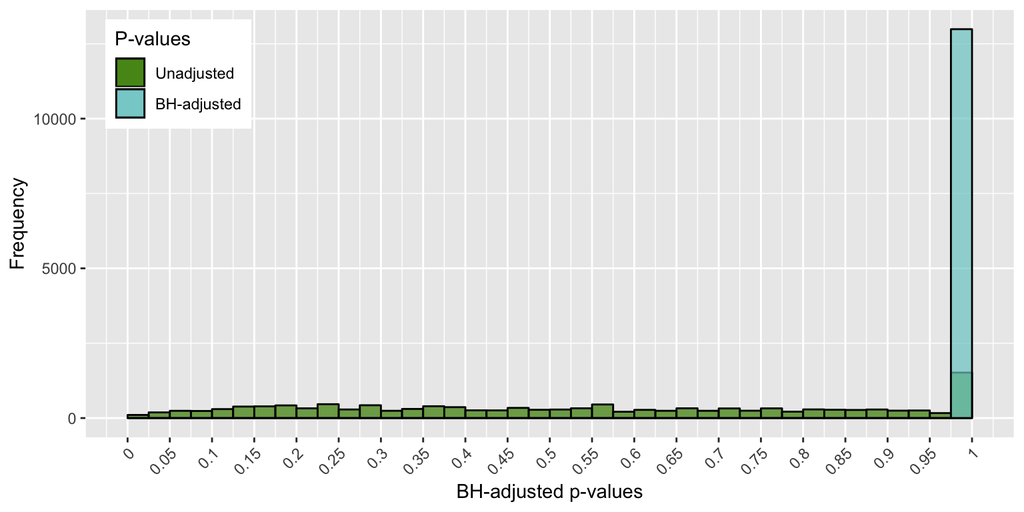

```r
wilcox_gene_plot <- ggplot(data = crispr_signif_del) +
  geom_histogram(aes(x = p, fill = "chartreuse4"), breaks = seq(0, 1, by = 0.025), color = "black", alpha = 0.7) +
  geom_histogram(aes(x = p.adj, fill = "darkslategray3"), breaks = seq(0, 1, by = 0.025), color = "black", alpha = 0.7) +
  scale_x_continuous(breaks = seq(0, 1, by = 0.05), labels = seq(0, 1, by = 0.05)) +
  scale_fill_manual(name = "P-values", values = c("chartreuse4" = "chartreuse4", "darkslategray3" = "darkslategray3"), labels = c("Unadjusted", "BH-adjusted")) +
  theme(axis.text.x = element_text(angle = 45, hjust = 1), legend.position = c(0.1, 0.85)) +
  labs(x = "BH-adjusted p-values", y = "Frequency")
wilcox_gene_plot
```

```r
# ggsave(filename = "./plots_18Q3/crispr/pvals_genes.pdf", plot = wilcox_gene_plot, width = 8, height = 4, device = "pdf")
```

### 4.1.2 Non-silent mutant vs. Other

```r
crispr_signif_nonsilent <- compare_means(Score ~ Mutation_Status_Nonsilent, group.by = c("Hugo_Symbol"), data = crispr_data_ptmuts, method = "wilcox.test", p.adjust.method = "BH")
crispr_signif_nonsilent <- adj_signif(crispr_signif_nonsilent)
crispr_signif_nonsilent <- crispr_signif_nonsilent[order(crispr_signif_nonsilent$p),]
saveRDS(crispr_signif_nonsilent, "./data_munging/rds/crispr_signif_nonsilent_gene.rds")

# write.table(crispr_signif_nonsilent, file = "~/Desktop/crispr_signif_nonsilent_gene.csv", quote = FALSE, sep = ",", row.names = FALSE)
```

```r
crispr_signif_nonsilent <- readRDS("./data_munging/rds/crispr_signif_nonsilent_gene.rds")

knitr::kable(filter(crispr_signif_nonsilent, p < 0.05)[, c("Hugo_Symbol", "p", "p.adj", "p.format", "p.signif", "p.signif.adj")], caption = "Wilcoxon test results comparing non-silent mutant and other cell lines, p < 0.05 (BH-adjusted p-values: * p <= 0.05, ** p <= 0.01, *** p <= 0.001, **** p <= 0.0001)") %>% kable_styling(bootstrap_options = c("striped", "hover", "condensed", "responsive")) %>% footnote(general = "Wilcoxon test Benjamini-Hochberg-corrected p-values:\n*: p <= 0.05\n**: p <= 0.01\n***: p <= 0.001\n****: p <= 0.0001") %>% scroll_box(width = "900px", height = "450px")
```

Wilcoxon test results comparing non-silent mutant and other cell lines, p < 0.05 (BH-adjusted p-values: * p <= 0.05, ** p <= 0.01, *** p <= 0.001, **** p <= 0.0001)

Hugo_Symbol

p

p.adj

p.format

p.signif

p.signif.adj

KMT2B

0.0001468

1

0.00015

***

NA

SLC12A3

0.0009262

1

0.00093

***

NA

HNRNPCL1

0.0015088

1

0.00151

NA

RGS12

0.0018901

1

0.00189

NA

EXOC3

0.0019090

1

0.00191

NA

TCERG1

0.0022235

1

0.00222

NA

ZNF560

0.0036554

1

0.00366

NA

EPHA5

0.0037993

1

0.00380

NA

C12orf4

0.0051890

1

0.00519

NA

VWCE

0.0063100

1

0.00631

NA

TJP3

0.0064667

1

0.00647

NA

FAM181B

0.0066551

1

0.00666

NA

IRS2

0.0068102

1

0.00681

NA

C2orf44

0.0069091

1

0.00691

NA

WFIKKN2

0.0077801

1

0.00778

NA

GPR152

0.0080099

1

0.00801

NA

CCM2L

0.0081382

1

0.00814

NA

NT5DC2

0.0083840

1

0.00838

NA

TOM1L1

0.0084748

1

0.00847

NA

FCGBP

0.0089536

1

0.00895

NA

KCNV2

0.0092945

1

0.00929

NA

MEF2C

0.0093314

1

0.00933

NA

EPS8L3

0.0097054

1

0.00971

NA

TSPAN12

0.0097565

1

0.00976

NA

NUP88

0.0103349

1

0.01033

NA

LRP12

0.0103961

1

0.01040

NA

C14orf39

0.0104695

1

0.01047

NA

CUL2

0.0104695

1

0.01047

NA

SCMH1

0.0105265

1

0.01053

NA

KRT19

0.0105337

1

0.01053

NA

SPATA4

0.0107334

1

0.01073

NA

MEX3B

0.0108964

1

0.01090

NA

SLC4A2

0.0109977

1

0.01100

NA

USP47

0.0110064

1

0.01101

NA

ZC3H4

0.0111545

1

0.01115

NA

FOXK2

0.0111590

1

0.01116

NA

RXRG

0.0112806

1

0.01128

NA

NXPE3

0.0112983

1

0.01130

NA

PGLYRP2

0.0112983

1

0.01130

NA

DLX5

0.0115400

1

0.01154

NA

NUP205

0.0118595

1

0.01186

NA

PTPRE

0.0121441

1

0.01214

NA

TUB

0.0124807

1

0.01248

NA

MKL2

0.0127073

1

0.01271

NA

CEP72

0.0132781

1

0.01328

NA

ZNF232

0.0137894

1

0.01379

NA

CHST8

0.0138833

1

0.01388

NA

STAM2

0.0140193

1

0.01402

NA

TBC1D10A

0.0140193

1

0.01402

NA

SOX9

0.0141779

1

0.01418

NA

FBXW4

0.0142140

1

0.01421

NA

HIST1H3G

0.0142140

1

0.01421

NA

PANK2

0.0142140

1

0.01421

NA

SHMT1

0.0142140

1

0.01421

NA

FAM161B

0.0142481

1

0.01425

NA

RNF133

0.0145321

1

0.01453

NA

CD4

0.0148355

1

0.01484

NA

PCK2

0.0149092

1

0.01491

NA

APBA1

0.0149172

1

0.01492

NA

MAML2

0.0149324

1

0.01493

NA

MEFV

0.0157143

1

0.01571

NA

PRKCZ

0.0157200

1

0.01572

NA

ZNF419

0.0157389

1

0.01574

NA

OR10J5

0.0157971

1

0.01580

NA

SLC16A14

0.0159858

1

0.01599

NA

SLC15A4

0.0160110

1

0.01601

NA

CNOT1

0.0163025

1

0.01630

NA

SPATA2

0.0163369

1

0.01634

NA

POU2F1

0.0164213

1

0.01642

NA

HIATL1

0.0166093

1

0.01661

NA

OR10C1

0.0167705

1

0.01677

NA

PHC2

0.0167890

1

0.01679

NA

PEAK1

0.0169258

1

0.01693

NA

C14orf37

0.0172588

1

0.01726

NA

CDH26

0.0172956

1

0.01730

NA

GSTM5

0.0173655

1

0.01737

NA

PINX1

0.0181630

1

0.01816

NA

AP2A1

0.0182644

1

0.01826

NA

ZEB2

0.0183165

1

0.01832

NA

SCUBE1

0.0185251

1

0.01853

NA

RBM33

0.0186071

1

0.01861

NA

ZNF568

0.0191481

1

0.01915

NA

CALCR

0.0192795

1

0.01928

NA

ARSJ

0.0196244

1

0.01962

NA

ZNF700

0.0196244

1

0.01962

NA

XPO1

0.0197345

1

0.01973

NA

CCNL1

0.0197808

1

0.01978

NA

ENAM

0.0197928

1

0.01979

NA

CR1

0.0198187

1

0.01982

NA

CD1B

0.0198735

1

0.01987

NA

ELK3

0.0199102

1

0.01991

NA

CD320

0.0199645

1

0.01996

NA

PARN

0.0201162

1

0.02012

NA

NRG2

0.0202011

1

0.02020

NA

TOX3

0.0202778

1

0.02028

NA

SPTBN4

0.0203213

1

0.02032

NA

DEPDC1

0.0204142

1

0.02041

NA

SPAST

0.0204637

1

0.02046

NA

CES2

0.0204680

1

0.02047

NA

PPP1R13L

0.0204924

1

0.02049

NA

ARMC3

0.0205423

1

0.02054

NA

VEGFB

0.0205964

1

0.02060

NA

PLXNB1

0.0207437

1

0.02074

NA

ERF

0.0213099

1

0.02131

NA

GPRIN2

0.0213871

1

0.02139

NA

TTC28

0.0214205

1

0.02142

NA

OR5B3

0.0218560

1

0.02186

NA

ROR1

0.0223731

1

0.02237

NA

CPNE9

0.0224789

1

0.02248

NA

RGS21

0.0224943

1

0.02249

NA

DPEP1

0.0226545

1

0.02265

NA

IL5RA

0.0226545

1

0.02265

NA

PLCD4

0.0226545

1

0.02265

NA

SNAP25

0.0226545

1

0.02265

NA

TIA1

0.0226545

1

0.02265

NA

DENND2A

0.0226895

1

0.02269

NA

HEATR5B

0.0226977

1

0.02270

NA

PEX6

0.0227903

1

0.02279

NA

KLF15

0.0230810

1

0.02308

NA

CNTNAP1

0.0231093

1

0.02311

NA

ARSB

0.0231629

1

0.02316

NA

MTF2

0.0232703

1

0.02327

NA

PIGO

0.0232906

1

0.02329

NA

KIAA1683

0.0233558

1

0.02336

NA

BCAR3

0.0234106

1

0.02341

NA

ORAI1

0.0234106

1

0.02341

NA

PRPF19

0.0234106

1

0.02341

NA

LCK

0.0234658

1

0.02347

NA

OR52I2

0.0238684

1

0.02387

NA

IMPG2

0.0240571

1

0.02406

NA

RP1L1

0.0241958

1

0.02420

NA

COG3

0.0242675

1

0.02427

NA

MORC2

0.0246516

1

0.02465

NA

CRLF3

0.0251815

1

0.02518

NA

NOLC1

0.0252007

1

0.02520

NA

PICK1

0.0252603

1

0.02526

NA

IRX3

0.0252712

1

0.02527

NA

TEKT3

0.0252712

1

0.02527

NA

TELO2

0.0252861

1

0.02529

NA

GPR141

0.0257358

1

0.02574

NA

FBXO30

0.0258965

1

0.02590

NA

PTCH1

0.0261041

1

0.02610

NA

FEM1B

0.0261845

1

0.02618

NA

ARMC2

0.0262242

1

0.02622

NA

FBXO34

0.0262602

1

0.02626

NA

CAMKMT

0.0265003

1

0.02650

NA

CEACAM6

0.0265003

1

0.02650

NA

REEP2

0.0265003

1

0.02650

NA

PCDHA3

0.0265116

1

0.02651

NA

CNGA3

0.0273471

1

0.02735

NA

DAAM1

0.0274105

1

0.02741

NA

KCNS3

0.0274686

1

0.02747

NA

ZNF470

0.0274686

1

0.02747

NA

LIPF

0.0275319

1

0.02753

NA

NEU2

0.0277377

1

0.02774

NA

PCNXL2

0.0277508

1

0.02775

NA

ARMC4

0.0278269

1

0.02783

NA

KIAA1279

0.0278923

1

0.02789

NA

ACD

0.0280601

1

0.02806

NA

ZFYVE1

0.0281001

1

0.02810

NA

TLE3

0.0281765

1

0.02818

NA

BSX

0.0281858

1

0.02819

NA

PPP1R8

0.0281858

1

0.02819

NA

RAB33B

0.0281858

1

0.02819

NA

SLC9C2

0.0283814

1

0.02838

NA

CACNA2D4

0.0283823

1

0.02838

NA

PIEZO1

0.0285905

1

0.02859

NA

CAPN11

0.0286576

1

0.02866

NA

F11R

0.0286881

1

0.02869

NA

COL9A2

0.0286949

1

0.02869

NA

OR4C3

0.0289870

1

0.02899

NA

BRD4

0.0290691

1

0.02907

NA

SLC24A1

0.0290963

1

0.02910

NA

GPR63

0.0292451

1

0.02925

NA

PQLC2

0.0297581

1

0.02976

NA

TPGS1

0.0297581

1

0.02976

NA

PMPCA

0.0298421

1

0.02984

NA

ADAMTSL3

0.0298966

1

0.02990

NA

RGPD2

0.0299488

1

0.02995

NA

GTF2H2C

0.0300279

1

0.03003

NA

MARK3

0.0301476

1

0.03015

NA

APBA2

0.0302173

1

0.03022

NA

SEL1L3

0.0302340

1

0.03023

NA

PURB

0.0304862

1

0.03049

NA

ST18

0.0305246

1

0.03052

NA

C8orf58

0.0305521

1

0.03055

NA

ACSBG2

0.0307039

1

0.03070

NA

RNF4

0.0307084

1

0.03071

NA

FAM171A1

0.0309508

1

0.03095

NA

PLK5

0.0312090

1

0.03121

NA

KLHL41

0.0312236

1

0.03122

NA

ZMYND15

0.0312236

1

0.03122

NA

RUFY3

0.0312294

1

0.03123

NA

SLC15A1

0.0313465

1

0.03135

NA

SLC7A1

0.0313598

1

0.03136

NA

FLT3

0.0314724

1

0.03147

NA

ZNF493

0.0315196

1

0.03152

NA

FIZ1

0.0315552

1

0.03156

NA

EEF2

0.0316232

1

0.03162

NA

TAS1R2

0.0317443

1

0.03174

NA

SMAD9

0.0320740

1

0.03207

NA

DDO

0.0320887

1

0.03209

NA

TBX20

0.0324262

1

0.03243

NA

MEF2A

0.0326119

1

0.03261

NA

TRAFD1

0.0327888

1

0.03279

NA

TRPM5

0.0327968

1

0.03280

NA

NUCB1

0.0328974

1

0.03290

NA

TRIOBP

0.0329216

1

0.03292

NA

ARFGAP1

0.0329694

1

0.03297

NA

ATMIN

0.0331389

1

0.03314

NA

MED15

0.0332413

1

0.03324

NA

CTNNB1

0.0333369

1

0.03334

NA

TLR1

0.0336042

1

0.03360

NA

MUS81

0.0336496

1

0.03365

NA

EPS8L2

0.0337362

1

0.03374

NA

ASB14

0.0337522

1

0.03375

NA

FANCC

0.0337522

1

0.03375

NA

KRT34

0.0337522

1

0.03375

NA

SLC22A9

0.0337522

1

0.03375

NA

RPUSD1

0.0337888

1

0.03379

NA

INPP5E

0.0338221

1

0.03382

NA

CCDC146

0.0340695

1

0.03407

NA

METTL17

0.0341540

1

0.03415

NA

SNX20

0.0342578

1

0.03426

NA

UPF1

0.0343090

1

0.03431

NA

CNTNAP3B

0.0343484

1

0.03435

NA

FCHO1

0.0344238

1

0.03442

NA

PARL

0.0344238

1

0.03442

NA

B3GAT3

0.0346106

1

0.03461

NA

CRNN

0.0346137

1

0.03461

NA

ARAP1

0.0346545

1

0.03465

NA

CKS1B

0.0348374

1

0.03484

NA

PATL1

0.0349959

1

0.03500

NA

ZNF808

0.0353176

1

0.03532

NA

HLCS

0.0353695

1

0.03537

NA

ATP5A1

0.0357638

1

0.03576

NA

CDC14B

0.0357638

1

0.03576

NA

PI16

0.0357638

1

0.03576

NA

TLX2

0.0357638

1

0.03576

NA

ATP6AP1L

0.0357701

1

0.03577

NA

UNKL

0.0358265

1

0.03583

NA

EIF4G3

0.0358452

1

0.03585

NA

COG7

0.0358888

1

0.03589

NA

GDF5

0.0359204

1

0.03592

NA

IFT140

0.0360521

1

0.03605

NA

OR51A4

0.0361966

1

0.03620

NA

NTN5

0.0363586

1

0.03636

NA

UMOD

0.0365375

1

0.03654

NA

ZNF229

0.0366794

1

0.03668

NA

XPO5

0.0367223

1

0.03672

NA

RCN1

0.0368884

1

0.03689

NA

UBE2Z

0.0368884

1

0.03689

NA

PEX14

0.0369043

1

0.03690

NA

OR2F1

0.0369820

1

0.03698

NA

HOXA5

0.0370407

1

0.03704

NA

ADCY8

0.0370802

1

0.03708

NA

MACC1

0.0371593

1

0.03716

NA

NFIC

0.0371667

1

0.03717

NA

DBX2

0.0372425

1

0.03724

NA

LDHAL6B

0.0372425

1

0.03724

NA

OR2L5

0.0373364

1

0.03734

NA

CSTF3

0.0376353

1

0.03764

NA

KIAA0355

0.0380751

1

0.03808

NA

GDF3

0.0382144

1

0.03821

NA

PIP5K1B

0.0382144

1

0.03821

NA

SPOCK3

0.0383702

1

0.03837

NA

CYP1A1

0.0385612

1

0.03856

NA

TG

0.0386297

1

0.03863

NA

ERC1

0.0388113

1

0.03881

NA

TRIM15

0.0388839

1

0.03888

NA

MAN2C1

0.0389628

1

0.03896

NA

SNX8

0.0389658

1

0.03897

NA

ACTA1

0.0390294

1

0.03903

NA

RELB

0.0392285

1

0.03923

NA

MFSD7

0.0392449

1

0.03924

NA

FASTKD3

0.0394025

1

0.03940

NA

L3MBTL4

0.0398326

1

0.03983

NA

SNX21

0.0400314

1

0.04003

NA

TMEM194A

0.0400314

1

0.04003

NA

AASDH

0.0400762

1

0.04008

NA

MPZL2

0.0402387

1

0.04024

NA

CACNB2

0.0402435

1

0.04024

NA

POU3F2

0.0403050

1

0.04030

NA

SLC52A2

0.0403050

1

0.04030

NA

AKNAD1

0.0405515

1

0.04055

NA

LRRCC1

0.0407213

1

0.04072

NA

ANKRD50

0.0410486

1

0.04105

NA

NAIF1

0.0411659

1

0.04117

NA

TCP10L2

0.0411842

1

0.04118

NA

CHPT1

0.0412580

1

0.04126

NA

CNBD2

0.0412580

1

0.04126

NA

KNSTRN

0.0412580

1

0.04126

NA

SERPINA5

0.0412580

1

0.04126

NA

SMG9

0.0412580

1

0.04126

NA

DCAF4

0.0414312

1

0.04143

NA

LPO

0.0415780

1

0.04158

NA

C2orf54

0.0416034

1

0.04160

NA

FAM205A

0.0416502

1

0.04165

NA

CCDC88A

0.0417383

1

0.04174

NA

ACLY

0.0419296

1

0.04193

NA

MCHR2

0.0419616

1

0.04196

NA

PKM

0.0419616

1

0.04196

NA

PADI3

0.0421983

1

0.04220

NA

PSAPL1

0.0422385

1

0.04224

NA

OR5D14

0.0426248

1

0.04262

NA

IQGAP3

0.0427033

1

0.04270

NA

KRT85

0.0427146

1

0.04271

NA

SNX30

0.0428256

1

0.04283

NA

CYP2J2

0.0429601

1

0.04296

NA

CORO7

0.0430141

1

0.04301

NA

ALDH9A1

0.0431214

1

0.04312

NA

ZFYVE27

0.0433081

1

0.04331

NA

SMC6

0.0434369

1

0.04344

NA

GARNL3

0.0435181

1

0.04352

NA

MFN1

0.0436613

1

0.04366

NA

GFRA1

0.0438890

1

0.04389

NA

GHR

0.0438890

1

0.04389

NA

ADRA2B

0.0439362

1

0.04394

NA

TET3

0.0441234

1

0.04412

NA

RALYL

0.0441713

1

0.04417

NA

NYNRIN

0.0441763

1

0.04418

NA

DTNB

0.0444785

1

0.04448

NA

ADSS

0.0446392

1

0.04464

NA

SLC22A16

0.0447106

1

0.04471

NA

ZNF814

0.0448920

1

0.04489

NA

FMNL2

0.0450476

1

0.04505

NA

MAP2K2

0.0451269

1

0.04513

NA

TBC1D7

0.0451269

1

0.04513

NA

IMMT

0.0453879

1

0.04539

NA

CHRM1

0.0454011

1

0.04540

NA

IBA57

0.0454360

1

0.04544

NA

SYDE1

0.0455892

1

0.04559

NA

YLPM1

0.0461029

1

0.04610

NA

MYOC

0.0464384

1

0.04644

NA

GRM1

0.0464874

1

0.04649

NA

ATG14

0.0465330

1

0.04653

NA

ECD

0.0468445

1

0.04684

NA

PPIL2

0.0472209

1

0.04722

NA

SEPT1

0.0472209

1

0.04722

NA

RABGAP1

0.0472391

1

0.04724

NA

WDR66

0.0473425

1

0.04734

NA

PAQR9

0.0474705

1

0.04747

NA

CDC37

0.0475369

1

0.04754

NA

LRRTM1

0.0476213

1

0.04762

NA

SLC22A15

0.0477173

1

0.04772

NA

ACTL8

0.0480388

1

0.04804

NA

ZNF395

0.0480598

1

0.04806

NA

SEMA7A

0.0480638

1

0.04806

NA

NSFL1C

0.0480802

1

0.04808

NA

ACMSD

0.0481324

1

0.04813

NA

FEZF2

0.0485396

1

0.04854

NA

TFR2

0.0485871

1

0.04859

NA

CATSPER1

0.0486717

1

0.04867

NA

EMR1

0.0488448

1

0.04884

NA

NOMO2

0.0489672

1

0.04897

NA

FKBP3

0.0490901

1

0.04909

NA

KRT83

0.0492535

1

0.04925

NA

PKNOX2

0.0494851

1

0.04949

NA

BCAN

0.0494941

1

0.04949

NA

ELMSAN1

0.0496272

1

0.04963

NA

PPFIBP2

0.0497165

1

0.04972

NA

DRC1

0.0498389

1

0.04984

NA

SEL1L2

0.0499043

1

0.04990

NA

SSH2

0.0499771

1

0.04998

NA

Note:

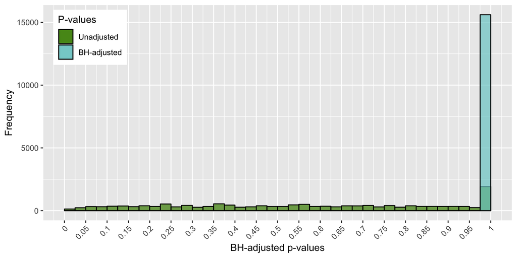

```r
wilcox_gene_nonsilent_plot <- ggplot(data = crispr_signif_nonsilent) +
  geom_histogram(aes(x = p, fill = "chartreuse4"), breaks = seq(0, 1, by = 0.025), color = "black", alpha = 0.7) +
  geom_histogram(aes(x = p.adj, fill = "darkslategray3"), breaks = seq(0, 1, by = 0.025), color = "black", alpha = 0.7) +
  scale_x_continuous(breaks = seq(0, 1, by = 0.05), labels = seq(0, 1, by = 0.05)) +
  # coord_cartesian(ylim = c(0, 3500)) +
  # scale_y_continuous(breaks = seq(0, 3500, by = 500), labels = formatC(seq(0, 3500, by = 500), format = "d")) +
  scale_fill_manual(name = "P-values", values = c("chartreuse4" = "chartreuse4", "darkslategray3" = "darkslategray3"), labels = c("Unadjusted", "BH-adjusted")) +
  theme(axis.text.x = element_text(angle = 45, hjust = 1), legend.position = c(0.1, 0.85)) +
  labs(x = "BH-adjusted p-values", y = "Frequency")
wilcox_gene_nonsilent_plot
```

### 4.1.3 Deleterious and missense mutant vs. Other

```r
crispr_signif_delmis <- compare_means(Score ~ Mutation_Status_DeleteriousMissense, group.by = c("Hugo_Symbol"), data = crispr_data_ptmuts, method = "wilcox.test", p.adjust.method = "BH")
crispr_signif_delmis <- adj_signif(crispr_signif_delmis)
crispr_signif_delmis <- crispr_signif_delmis[order(crispr_signif_delmis$p),]
saveRDS(crispr_signif_delmis, "./data_munging/rds/crispr_signif_deleteriousmissense_gene.rds")

# write.table(crispr_signif_delmis, file = "~/Desktop/crispr_signif_deleteriousmissense_gene.csv", quote = FALSE, sep = ",", row.names = FALSE)
```

```r
crispr_signif_delmis <- readRDS("./data_munging/rds/crispr_signif_deleteriousmissense_gene.rds")

knitr::kable(filter(crispr_signif_delmis, p < 0.05)[, c("Hugo_Symbol", "p", "p.adj", "p.format", "p.signif", "p.signif.adj")], caption = "Wilcoxon test results comparing deleterious and missense mutant and other cell lines, p < 0.05 (BH-adjusted p-values: * p <= 0.05, ** p <= 0.01, *** p <= 0.001, **** p <= 0.0001)") %>% kable_styling(bootstrap_options = c("striped", "hover", "condensed", "responsive")) %>% footnote(general = "Wilcoxon test Benjamini-Hochberg-corrected p-values:\n*: p <= 0.05\n**: p <= 0.01\n***: p <= 0.001\n****: p <= 0.0001") %>% scroll_box(width = "900px", height = "450px")
```

Wilcoxon test results comparing deleterious and missense mutant and other cell lines, p < 0.05 (BH-adjusted p-values: * p <= 0.05, ** p <= 0.01, *** p <= 0.001, **** p <= 0.0001)

Hugo_Symbol

p

p.adj

p.format

p.signif

p.signif.adj

KMT2B

0.0001468

1

0.00015

***

NA

SLC12A3

0.0009262

1

0.00093

***

NA

HNRNPCL1

0.0015088

1

0.00151

NA

RGS12

0.0018901

1

0.00189

NA

EXOC3

0.0019090

1

0.00191

NA

TCERG1

0.0022235

1

0.00222

NA

NT5DC2

0.0034482

1

0.00345

NA

ZNF560

0.0036554

1

0.00366

NA

EPHA5

0.0037993

1

0.00380

NA

C12orf4

0.0051890

1

0.00519

NA

VWCE

0.0063100

1

0.00631

NA

TJP3

0.0064667

1

0.00647

NA

FAM181B

0.0066551

1

0.00666

NA

IRS2

0.0068102

1

0.00681

NA

C2orf44

0.0069091

1

0.00691

NA

WFIKKN2

0.0077801

1

0.00778

NA

GPR152

0.0080099

1

0.00801

NA

TOM1L1

0.0084748

1

0.00847

NA

FCGBP

0.0089536

1

0.00895

NA

KCNV2

0.0092945

1

0.00929

NA

MEF2C

0.0093314

1

0.00933

NA

CCM2L

0.0093630

1

0.00936

NA

EPS8L3

0.0097054

1

0.00971

NA

TSPAN12

0.0097565

1

0.00976

NA

NUP88

0.0103349

1

0.01033

NA

LRP12

0.0103961

1

0.01040

NA

C14orf39

0.0104695

1

0.01047

NA

CUL2

0.0104695

1

0.01047

NA

IQGAP3

0.0104805

1

0.01048

NA

SCMH1

0.0105265

1

0.01053

NA

KRT19

0.0105337

1

0.01053

NA

SPATA4

0.0107334

1

0.01073

NA

MEX3B

0.0108964

1

0.01090

NA

SLC4A2

0.0109977

1

0.01100

NA

USP47

0.0110064

1

0.01101

NA

ZC3H4

0.0111545

1

0.01115

NA

FOXK2

0.0111590

1

0.01116

NA

RXRG

0.0112806

1

0.01128

NA

NXPE3

0.0112983

1

0.01130

NA

PGLYRP2

0.0112983

1

0.01130

NA

DLX5

0.0115400

1

0.01154

NA

PTPRE

0.0121441

1

0.01214

NA

TUB

0.0124807

1

0.01248

NA

MKL2

0.0127073

1

0.01271

NA

NUP205

0.0128458

1

0.01285

NA

ZNF232

0.0137894

1

0.01379

NA

CHST8

0.0138833

1

0.01388

NA

STAM2

0.0140193

1

0.01402

NA

TBC1D10A

0.0140193

1

0.01402

NA

SOX9

0.0141779

1

0.01418

NA

HIST1H3G

0.0142140

1

0.01421

NA

PANK2

0.0142140

1

0.01421

NA

SHMT1

0.0142140

1

0.01421

NA

FAM161B

0.0142481

1

0.01425

NA

RNF133

0.0145321

1

0.01453

NA

CD4

0.0148355

1

0.01484

NA

PCK2

0.0149092

1

0.01491

NA

APBA1

0.0149172

1

0.01492

NA

ECD

0.0153927

1

0.01539

NA

MEFV

0.0157143

1

0.01571

NA

PRKCZ

0.0157200

1

0.01572

NA

ZNF419

0.0157389

1

0.01574

NA

OR10J5

0.0157971

1

0.01580

NA

SLC16A14

0.0159858

1

0.01599

NA

SLC15A4

0.0160110

1

0.01601

NA

CNOT1

0.0163025

1

0.01630

NA

SPATA2

0.0163369

1

0.01634

NA

POU2F1

0.0164213

1

0.01642

NA

HIATL1

0.0166093

1

0.01661

NA

OR10C1

0.0167705

1

0.01677

NA

PHC2

0.0167890

1

0.01679

NA

PEAK1

0.0169258

1

0.01693

NA

NOL7

0.0172390

1

0.01724

NA

C14orf37

0.0172588

1

0.01726

NA

CDH26

0.0172956

1

0.01730

NA

CEP72

0.0173561

1

0.01736

NA

GSTM5

0.0173655

1

0.01737

NA

PINX1

0.0181630

1

0.01816

NA

AP2A1

0.0182644

1

0.01826

NA

ZEB2

0.0183165

1

0.01832

NA

SCUBE1

0.0185251

1

0.01853

NA

RBM33

0.0186071

1

0.01861

NA

ZNF568

0.0191481

1

0.01915

NA

CALCR

0.0192795

1

0.01928

NA

ARSJ

0.0196244

1

0.01962

NA

ZNF700

0.0196244

1

0.01962

NA

XPO1

0.0197345

1

0.01973

NA

CCNL1

0.0197808

1

0.01978

NA

ENAM

0.0197928

1

0.01979

NA

CD1B

0.0198735

1

0.01987

NA

ELK3

0.0199102

1

0.01991

NA

CD320

0.0199645

1

0.01996

NA

PARN

0.0201162

1

0.02012

NA

NRG2

0.0202011

1

0.02020

NA

TOX3

0.0202778

1

0.02028

NA

SPTBN4

0.0203213

1

0.02032

NA

DEPDC1

0.0204142

1

0.02041

NA

SPAST

0.0204637

1

0.02046

NA

CES2

0.0204680

1

0.02047

NA

ARMC3

0.0205423

1

0.02054

NA

VEGFB

0.0205964

1

0.02060

NA

PLXNB1

0.0207437

1

0.02074

NA

ERF

0.0213099

1

0.02131

NA

GPRIN2

0.0213871

1

0.02139

NA

TTC28

0.0214205

1

0.02142

NA

OR5B3

0.0218560

1

0.02186

NA

ROR1

0.0223731

1

0.02237

NA

CPNE9

0.0224789

1

0.02248

NA

RGS21

0.0224943

1

0.02249

NA

DPEP1

0.0226545

1

0.02265

NA

IL5RA

0.0226545

1

0.02265

NA

PLCD4

0.0226545

1

0.02265

NA

SNAP25

0.0226545

1

0.02265

NA

TIA1

0.0226545

1

0.02265

NA

DENND2A

0.0226895

1

0.02269

NA

HEATR5B

0.0226977

1

0.02270

NA

PEX6

0.0227903

1

0.02279

NA

KLF15

0.0230810

1

0.02308

NA

CNTNAP1

0.0231093

1

0.02311

NA

ARSB

0.0231629

1

0.02316

NA

MTF2

0.0232703

1

0.02327

NA

PIGO

0.0232906

1

0.02329

NA

KIAA1683

0.0233558

1

0.02336

NA

BCAR3

0.0234106

1

0.02341

NA

ORAI1

0.0234106

1

0.02341

NA

PRPF19

0.0234106

1

0.02341

NA

LCK

0.0234658

1

0.02347

NA

OR52I2

0.0238684

1

0.02387

NA

IMPG2

0.0240571

1

0.02406

NA

COG3

0.0242675

1

0.02427

NA

MORC2

0.0246516

1

0.02465

NA

RP1L1

0.0247846

1

0.02478

NA

CRLF3

0.0251815

1

0.02518

NA

PICK1

0.0252603

1

0.02526

NA

IRX3

0.0252712

1

0.02527

NA

TEKT3

0.0252712

1

0.02527

NA

TELO2

0.0252861

1

0.02529

NA

GPR141

0.0257358

1

0.02574

NA

FBXO30

0.0258965

1

0.02590

NA

PTCH1

0.0261041

1

0.02610

NA

ARMC2

0.0262242

1

0.02622

NA

FBXO34

0.0262602

1

0.02626

NA

CAMKMT

0.0265003

1

0.02650

NA

CEACAM6

0.0265003

1

0.02650

NA

REEP2

0.0265003

1

0.02650

NA

PCDHA3

0.0265116

1

0.02651

NA

HMX3

0.0268091

1

0.02681

NA

C21orf58

0.0272754

1

0.02728

NA

CNGA3

0.0273471

1

0.02735

NA

DAAM1

0.0274105

1

0.02741

NA

KCNS3

0.0274686

1

0.02747

NA

ZNF470

0.0274686

1

0.02747

NA

LIPF

0.0275319

1

0.02753

NA

NEU2

0.0277377

1

0.02774

NA

PPP1R13L

0.0277440

1

0.02774

NA

PCNXL2

0.0277508

1

0.02775

NA

ARMC4

0.0278269

1

0.02783

NA

KIAA1279

0.0278923

1

0.02789

NA

ZFYVE1

0.0281001

1

0.02810

NA

TLE3

0.0281765

1

0.02818

NA

BSX

0.0281858

1

0.02819

NA

PPP1R8

0.0281858

1

0.02819

NA

RAB33B

0.0281858

1

0.02819

NA

SLC9C2

0.0283814

1

0.02838

NA

CACNA2D4

0.0283823

1

0.02838

NA

PIEZO1

0.0285905

1

0.02859

NA

CAPN11

0.0286576

1

0.02866

NA

COL9A2

0.0286949

1

0.02869

NA

OR4C3

0.0289870

1

0.02899

NA

BRD4

0.0290691

1

0.02907

NA

SLC24A1

0.0290963

1

0.02910

NA

GPR63

0.0292451

1

0.02925

NA

PQLC2

0.0297581

1

0.02976

NA

TPGS1

0.0297581

1

0.02976

NA

PMPCA

0.0298421

1

0.02984

NA

ADAMTSL3

0.0298966

1

0.02990

NA

KRT85

0.0299423

1

0.02994

NA

RGPD2

0.0299488

1

0.02995

NA

GTF2H2C

0.0300279

1

0.03003

NA

MARK3

0.0301476

1

0.03015

NA

APBA2

0.0302173

1

0.03022

NA

SEL1L3

0.0302340

1

0.03023

NA

SEL1L2

0.0304107

1

0.03041

NA

PURB

0.0304862

1

0.03049

NA

ST18

0.0305246

1

0.03052

NA

C8orf58

0.0305521

1

0.03055

NA

ACSBG2

0.0307039

1

0.03070

NA

RNF4

0.0307084

1

0.03071

NA

FAM171A1

0.0309508

1

0.03095

NA

PLK5

0.0312090

1

0.03121

NA

KLHL41

0.0312236

1

0.03122

NA

ZMYND15

0.0312236

1

0.03122

NA

SLC15A1

0.0313465

1

0.03135

NA

SLC7A1

0.0313598

1

0.03136

NA

FLT3

0.0314724

1

0.03147

NA

FIZ1

0.0315552

1

0.03156

NA

EEF2

0.0316232

1

0.03162

NA

TAS1R2

0.0317443

1

0.03174

NA

FAM131A

0.0319353

1

0.03194

NA

SMAD9

0.0320740

1

0.03207

NA

DDO

0.0320887

1

0.03209

NA

TBX20

0.0324262

1

0.03243

NA

MEF2A

0.0326119

1

0.03261

NA

TRAFD1

0.0327888

1

0.03279

NA

TRPM5

0.0327968

1

0.03280

NA

NUCB1

0.0328974

1

0.03290

NA

TRIOBP

0.0329216

1

0.03292

NA

ARFGAP1

0.0329694

1

0.03297

NA

ATMIN

0.0331389

1

0.03314

NA

MED15

0.0332413

1

0.03324

NA

CTNNB1

0.0333369

1

0.03334

NA

TLR1

0.0336042

1

0.03360

NA

MUS81

0.0336496

1

0.03365

NA

EPS8L2

0.0337362

1

0.03374

NA

ASB14

0.0337522

1

0.03375

NA

FANCC

0.0337522

1

0.03375

NA

KRT34

0.0337522

1

0.03375

NA

SLC22A9

0.0337522

1

0.03375

NA

ZNF80

0.0337522

1

0.03375

NA

RPUSD1

0.0337888

1

0.03379

NA

INPP5E

0.0338221

1

0.03382

NA

CCDC146

0.0340695

1

0.03407

NA

METTL17

0.0341540

1

0.03415

NA

SNX20

0.0342578

1

0.03426

NA

CNTNAP3B

0.0343484

1

0.03435

NA

FCHO1

0.0344238

1

0.03442

NA

PARL

0.0344238

1

0.03442

NA

B3GAT3

0.0346106

1

0.03461

NA

CRNN

0.0346137

1

0.03461

NA

ARAP1

0.0346545

1

0.03465

NA

CKS1B

0.0348374

1

0.03484

NA

ISM2

0.0349838

1

0.03498

NA

PATL1

0.0349959

1

0.03500

NA

ZNF808

0.0353176

1

0.03532

NA

HLCS

0.0353695

1

0.03537

NA

ATP5A1

0.0357638

1

0.03576

NA

CDC14B

0.0357638

1

0.03576

NA

PI16

0.0357638

1

0.03576

NA

TLX2

0.0357638

1

0.03576

NA

ATP6AP1L

0.0357701

1

0.03577

NA

UNKL

0.0358265

1

0.03583

NA

EIF4G3

0.0358452

1

0.03585

NA

COG7

0.0358888

1

0.03589

NA

GDF5

0.0359204

1

0.03592

NA

IFT140

0.0360521

1

0.03605

NA

OR51A4

0.0361966

1

0.03620

NA

NTN5

0.0363586

1

0.03636

NA

UMOD

0.0365375

1

0.03654

NA

TRA2B

0.0365460

1

0.03655

NA

ZNF229

0.0366794

1

0.03668

NA

XPO5

0.0367223

1

0.03672

NA

UBE2Z

0.0368884

1

0.03689

NA

OR2F1

0.0369820

1

0.03698

NA

HOXA5

0.0370407

1

0.03704

NA

ADCY8

0.0370802

1

0.03708

NA

MACC1

0.0371593

1

0.03716

NA

NFIC

0.0371667

1

0.03717

NA

DBX2

0.0372425

1

0.03724

NA

LDHAL6B

0.0372425

1

0.03724

NA

SLC30A4

0.0372599

1

0.03726

NA

OR2L5

0.0373364

1

0.03734

NA

F11R

0.0374740

1

0.03747

NA

CSTF3

0.0376353

1

0.03764

NA

KIAA0355

0.0380751

1

0.03808

NA

GDF3

0.0382144

1

0.03821

NA

SPOCK3

0.0383702

1

0.03837

NA

CYP1A1

0.0385612

1

0.03856

NA

TG

0.0386297

1

0.03863

NA

ERC1

0.0388113

1

0.03881

NA

TRIM15

0.0388839

1

0.03888

NA

MAN2C1

0.0389628

1

0.03896

NA

SNX8

0.0389658

1

0.03897

NA

ACTA1

0.0390294

1

0.03903

NA

RELB

0.0392285

1

0.03923

NA

MFSD7

0.0392449

1

0.03924

NA

FASTKD3

0.0394025

1

0.03940

NA

L3MBTL4

0.0398326

1

0.03983

NA

SNX21

0.0400314

1

0.04003

NA

TMEM194A

0.0400314

1

0.04003

NA

AASDH

0.0400762

1

0.04008

NA

MPZL2

0.0402387

1

0.04024

NA

CACNB2

0.0402435

1

0.04024

NA

POU3F2

0.0403050

1

0.04030

NA

SLC52A2

0.0403050

1

0.04030

NA

AKNAD1

0.0405515

1

0.04055

NA

LRRCC1

0.0407213

1

0.04072

NA

ANKRD50

0.0410486

1

0.04105

NA

NAIF1

0.0411659

1

0.04117

NA

CHPT1

0.0412580

1

0.04126

NA

CNBD2

0.0412580

1

0.04126

NA

KNSTRN

0.0412580

1

0.04126

NA

SMG9

0.0412580

1

0.04126

NA

DCAF4

0.0414312

1

0.04143

NA

ACD

0.0414779

1

0.04148

NA

LPO

0.0415780

1

0.04158

NA

C2orf54

0.0416034

1

0.04160

NA

FAM205A

0.0416502

1

0.04165

NA

CCDC88A

0.0417383

1

0.04174

NA

ACLY

0.0419296

1

0.04193

NA

MCHR2

0.0419616

1

0.04196

NA

PKM

0.0419616

1

0.04196

NA

SERPINA5

0.0419616

1

0.04196

NA

PADI3

0.0421983

1

0.04220

NA

PSAPL1

0.0422385

1

0.04224

NA

OR5D14

0.0426248

1

0.04262

NA

SNX30

0.0428256

1

0.04283

NA

FEM1B

0.0429241

1

0.04292

NA

CYP2J2

0.0429601

1

0.04296

NA

CORO7

0.0430141

1

0.04301

NA

ALDH9A1

0.0431214

1

0.04312

NA

ZFYVE27

0.0433081

1

0.04331

NA

SMC6

0.0434369

1

0.04344

NA

GARNL3

0.0435181

1

0.04352

NA

MFN1

0.0436613

1

0.04366

NA

GFRA1

0.0438890

1

0.04389

NA

GHR

0.0438890

1

0.04389

NA

ADRA2B

0.0439362

1

0.04394

NA

TET3

0.0441234

1

0.04412

NA

RALYL

0.0441713

1

0.04417

NA

NYNRIN

0.0441763

1

0.04418

NA

DTNB

0.0444785

1

0.04448

NA

ADSS

0.0446392

1

0.04464

NA

SLC22A16

0.0447106

1

0.04471

NA

BRCA1

0.0450320

1

0.04503

NA

FMNL2

0.0450476

1

0.04505

NA

MAP2K2

0.0451269

1

0.04513

NA

TBC1D7

0.0451269

1

0.04513

NA

IMMT

0.0453879

1

0.04539

NA

CHRM1

0.0454011

1

0.04540

NA

IBA57

0.0454360

1

0.04544

NA

SYDE1

0.0455892

1

0.04559

NA

CR1

0.0460075

1

0.04601

NA

YLPM1

0.0461029

1

0.04610

NA

MYOC

0.0464384

1

0.04644

NA

GRM1

0.0464874

1

0.04649

NA

ATG14

0.0465330

1

0.04653

NA

PPIL2

0.0472209

1

0.04722

NA

SEPT1

0.0472209

1

0.04722

NA

RABGAP1

0.0472391

1

0.04724

NA

WDR66

0.0473425

1

0.04734

NA

PAQR9

0.0474705

1

0.04747

NA

CDC37

0.0475369

1

0.04754

NA

LRRTM1

0.0476213

1

0.04762

NA

SLC22A15

0.0477173

1

0.04772

NA

ACTL8

0.0480388

1

0.04804

NA

ZNF395

0.0480598

1

0.04806

NA

SEMA7A

0.0480638

1

0.04806

NA

NSFL1C

0.0480802

1

0.04808

NA

PRUNE2

0.0480863

1

0.04809

NA

ACMSD

0.0481324

1

0.04813

NA

FEZF2

0.0485396

1

0.04854

NA

TFR2

0.0485871

1

0.04859

NA

CATSPER1

0.0486717

1

0.04867

NA

UPF1

0.0487801

1

0.04878

NA

EMR1

0.0488448

1

0.04884

NA

NOMO2

0.0489672

1

0.04897

NA

FKBP3

0.0490901

1

0.04909

NA

KRT83

0.0492535

1

0.04925

NA

PKNOX2

0.0494851

1

0.04949

NA

BCAN

0.0494941

1

0.04949

NA

PPFIBP2

0.0497165

1

0.04972

NA

DRC1

0.0498389

1

0.04984

NA

SSH2

0.0499771

1

0.04998

NA

Note:

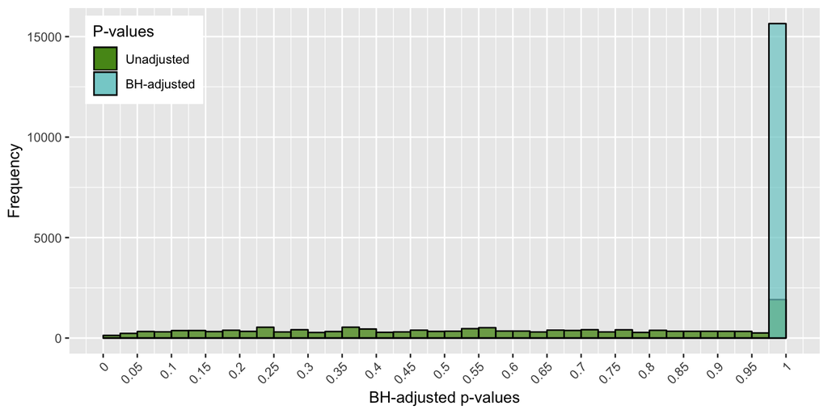

```r
wilcox_gene_delmis_plot <- ggplot(data = crispr_signif_delmis) +
  geom_histogram(aes(x = p, fill = "chartreuse4"), breaks = seq(0, 1, by = 0.025), color = "black", alpha = 0.7) +
  geom_histogram(aes(x = p.adj, fill = "darkslategray3"), breaks = seq(0, 1, by = 0.025), color = "black", alpha = 0.7) +
  scale_x_continuous(breaks = seq(0, 1, by = 0.05), labels = seq(0, 1, by = 0.05)) +
  # coord_cartesian(ylim = c(0, 3500)) +
  # scale_y_continuous(breaks = seq(0, 3500, by = 500), labels = formatC(seq(0, 3500, by = 500), format = "d")) +
  scale_fill_manual(name = "P-values", values = c("chartreuse4" = "chartreuse4", "darkslategray3" = "darkslategray3"), labels = c("Unadjusted", "BH-adjusted")) +
  theme(axis.text.x = element_text(angle = 45, hjust = 1), legend.position = c(0.1, 0.85)) +
  labs(x = "BH-adjusted p-values", y = "Frequency")
wilcox_gene_delmis_plot
```

## 4.2 Grouped by gene and lineage

### 4.2.1 Deleterious vs. Other

```r
crispr_signif_del_lineage <- compare_means(Score ~ Mutation_Status_Deleterious, group.by = c("Hugo_Symbol", "group_general_lineage_name"), data = crispr_data_ptmuts, method = "wilcox.test", p.adjust.method = "BH")
crispr_signif_del_lineage <- adj_signif(crispr_signif_del_lineage)
crispr_signif_del_lineage <- crispr_signif_del_lineage[order(crispr_signif_del_lineage$p),]
saveRDS(crispr_signif_del_lineage, "./data_munging/rds/crispr_signif_deleterious_lineage.rds")

# write.table(crispr_signif_del_lineage, file = "~/Desktop/crispr_signif_deleterious_lineage.csv", quote = FALSE, sep = ",", row.names = FALSE)
```

```r
crispr_signif_del_lineage <- readRDS("./data_munging/rds/crispr_signif_deleterious_lineage.rds")

knitr::kable(filter(crispr_signif_del_lineage, p < 0.05)[, c("Hugo_Symbol", "group_general_lineage_name", "p", "p.adj", "p.format", "p.signif", "p.signif.adj")], caption = "Wilcoxon test results comparing deleterious mutant and other cell lines by lineage, p < 0.05 (BH-adjusted p-values: * p <= 0.05, ** p <= 0.01, *** p <= 0.001, **** p <= 0.0001)") %>% kable_styling(bootstrap_options = c("striped", "hover", "condensed", "responsive")) %>% footnote(general = "Wilcoxon test Benjamini-Hochberg-corrected p-values:\n*: p <= 0.05\n**: p <= 0.01\n***: p <= 0.001\n****: p <= 0.0001") %>% scroll_box(width = "900px", height = "450px")
```

Wilcoxon test results comparing deleterious mutant and other cell lines by lineage, p < 0.05 (BH-adjusted p-values: * p <= 0.05, ** p <= 0.01, *** p <= 0.001, **** p <= 0.0001)

Hugo_Symbol

group_general_lineage_name

p

p.adj

p.format

p.signif

p.signif.adj

PTEN

central nervous system cancer

0.0073526

1

0.0074

NA

DCAF8

lung cancer

0.0127807

1

0.0128

NA

KMT2D

lung cancer

0.0155311

1

0.0155

NA

RERE

colorectal cancer

0.0199645

1

0.0200

NA

COL15A1

uterine cancer

0.0222455

1

0.0222

NA

BAZ2B

lung cancer

0.0230287

1

0.0230

NA

SCN10A

uterine cancer

0.0325499

1

0.0325

NA

RUNX2

uterine cancer

0.0368884

1

0.0369

NA

FRMD4A

uterine cancer

0.0408331

1

0.0408

NA

TP53

lung cancer

0.0420128

1

0.0420

NA

TP53

skin cancer

0.0428256

1

0.0428

NA

MED12L

lung cancer

0.0446392

1

0.0446

NA

RALGAPB

uterine cancer

0.0457185

1

0.0457

NA

SMARCA4

lung cancer

0.0475939

1

0.0476

NA

ASXL3

colorectal cancer

0.0487981

1

0.0488

NA

BRD4

uterine cancer

0.0487981

1

0.0488

NA

ST5

uterine cancer

0.0488846

1

0.0489

NA

KNOP1

uterine cancer

0.0497460

1

0.0497

NA

Note:

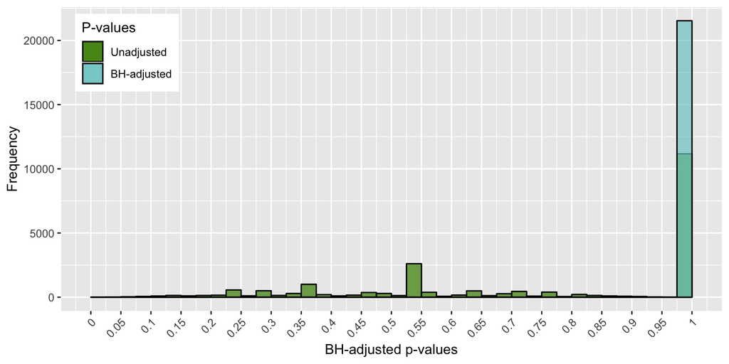

```r
wilcox_lineage_plot <- ggplot(data = crispr_signif_del_lineage) +
  geom_histogram(aes(x = p, fill = "chartreuse4"), breaks = seq(0, 1, by = 0.025), color = "black", alpha = 0.7) +
  geom_histogram(aes(x = p.adj, fill = "darkslategray3"), breaks = seq(0, 1, by = 0.025), color = "black", alpha = 0.7) +
  scale_x_continuous(breaks = seq(0, 1, by = 0.05), labels = seq(0, 1, by = 0.05)) +
  # coord_cartesian(ylim = c(0, 3500)) +
  # scale_y_continuous(breaks = seq(0, 3500, by = 500), labels = formatC(seq(0, 3500, by = 500), format = "d")) +
  scale_fill_manual(name = "P-values", values = c("chartreuse4" = "chartreuse4", "darkslategray3" = "darkslategray3"), labels = c("Unadjusted", "BH-adjusted")) +
  theme(axis.text.x = element_text(angle = 45, hjust = 1), legend.position = c(0.1, 0.85)) +
  labs(x = "BH-adjusted p-values", y = "Frequency")
wilcox_lineage_plot
```

```r
# ggsave(filename = "./plots_18Q3/crispr/pvals_genes.pdf", plot = wilcox_gene_plot, width = 8, height = 4, device = "pdf")
```

### 4.2.2 Non-silent mutant vs. Other

```r
crispr_signif_nonsilent_lineage <- compare_means(Score ~ Mutation_Status_Nonsilent, group.by = c("Hugo_Symbol", "group_general_lineage_name"), data = crispr_data_ptmuts, method = "wilcox.test", p.adjust.method = "BH")
crispr_signif_nonsilent_lineage <- adj_signif(crispr_signif_nonsilent_lineage)
crispr_signif_nonsilent_lineage <- crispr_signif_nonsilent_lineage[order(crispr_signif_nonsilent_lineage$p),]
saveRDS(crispr_signif_nonsilent_lineage, "./data_munging/rds/crispr_signif_nonsilent_lineage.rds")

# write.table(crispr_signif_nonsilent_lineage, file = "~/Desktop/crispr_signif_nonsilent_lineage.csv", quote = FALSE, sep = ",", row.names = FALSE)
```

```r
crispr_signif_nonsilent_lineage <- readRDS("./data_munging/rds/crispr_signif_nonsilent_lineage.rds")

knitr::kable(filter(crispr_signif_nonsilent_lineage, p < 0.05)[, c("Hugo_Symbol", "group_general_lineage_name", "p", "p.adj", "p.format", "p.signif", "p.signif.adj")], caption = "Wilcoxon test results comparing non-silent mutant and other cell lines by lineage, p < 0.05 (BH-adjusted p-values: * p <= 0.05, ** p <= 0.01, *** p <= 0.001, **** p <= 0.0001)") %>% kable_styling(bootstrap_options = c("striped", "hover", "condensed", "responsive")) %>% footnote(general = "Wilcoxon test Benjamini-Hochberg-corrected p-values:\n*: p <= 0.05\n**: p <= 0.01\n***: p <= 0.001\n****: p <= 0.0001") %>% scroll_box(width = "900px", height = "450px")
```

Wilcoxon test results comparing non-silent mutant and other cell lines by lineage, p < 0.05 (BH-adjusted p-values: * p <= 0.05, ** p <= 0.01, *** p <= 0.001, **** p <= 0.0001)

Hugo_Symbol

group_general_lineage_name

p

p.adj

p.format

p.signif

p.signif.adj

SYNE1

lung cancer

0.0140032

1

0.014

NA

PKHD1

lung cancer

0.0154975

1

0.015

NA

RP1L1

lung cancer

0.0163009

1

0.016

NA

BIRC6

lung cancer

0.0187768

1

0.019

NA

NOS1

lung cancer

0.0224943

1

0.022

NA

KMT2B

breast cancer

0.0265187

1

0.027

NA

KMT2D

ovarian cancer

0.0273481

1

0.027

NA

TRPA1

lung cancer

0.0281858

1

0.028

NA

PLEC

kidney cancer

0.0303828

1

0.030

NA

TENM4

skin cancer

0.0349263

1

0.035

NA

NEBL

uterine cancer

0.0362034

1

0.036

NA

ADAM11

lung cancer

0.0368884

1

0.037

NA

TJP1

uterine cancer

0.0372492

1

0.037

NA

XYLT2

uterine cancer

0.0372492

1

0.037

NA

LPHN3

lung cancer

0.0375182

1

0.038

NA

SALL4

lung cancer

0.0380559

1

0.038

NA

MMP16

lung cancer

0.0382144

1

0.038

NA

BMPER

lung cancer

0.0396348

1

0.040

NA

POLE

uterine cancer

0.0398748

1

0.040

NA

CMYA5

lung cancer

0.0412580

1

0.041

NA

HCN1

lung cancer

0.0419663

1

0.042

NA

TBC1D9

colorectal cancer

0.0419967

1

0.042

NA

KIAA0100

uterine cancer

0.0420664

1

0.042

NA

CHD5

colorectal cancer

0.0428256

1

0.043

NA

GLI3

colorectal cancer

0.0458662

1

0.046

NA

RRBP1

uterine cancer

0.0491854

1

0.049

NA

ARMC4

uterine cancer

0.0497460

1

0.050

NA

BRINP2

skin cancer

0.0497460

1

0.050

NA

Note:

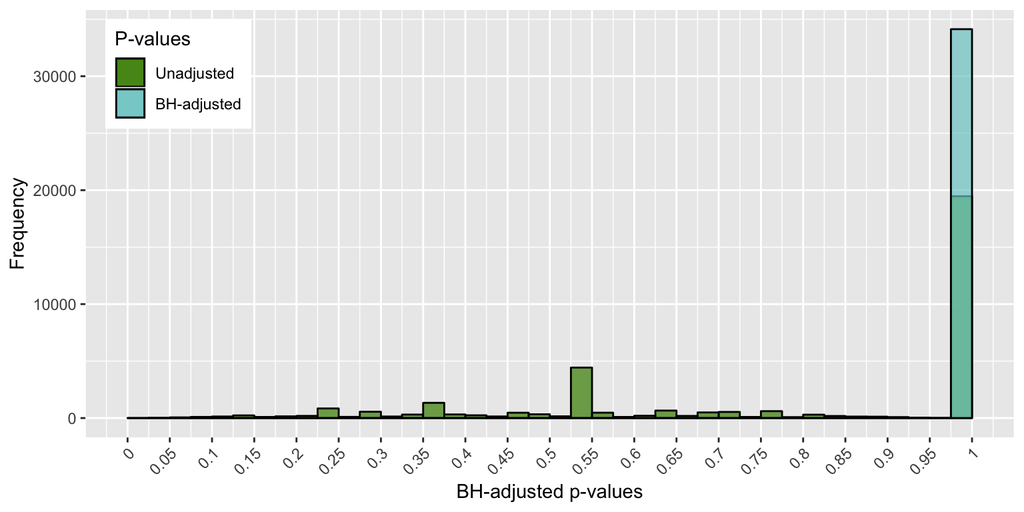

```r
wilcox_lineage_nonsilent_plot <- ggplot(data = crispr_signif_nonsilent_lineage) +
  geom_histogram(aes(x = p, fill = "chartreuse4"), breaks = seq(0, 1, by = 0.025), color = "black", alpha = 0.7) +
  geom_histogram(aes(x = p.adj, fill = "darkslategray3"), breaks = seq(0, 1, by = 0.025), color = "black", alpha = 0.7) +
  scale_x_continuous(breaks = seq(0, 1, by = 0.05), labels = seq(0, 1, by = 0.05)) +
  # coord_cartesian(ylim = c(0, 3500)) +
  # scale_y_continuous(breaks = seq(0, 3500, by = 500), labels = formatC(seq(0, 3500, by = 500), format = "d")) +
  scale_fill_manual(name = "P-values", values = c("chartreuse4" = "chartreuse4", "darkslategray3" = "darkslategray3"), labels = c("Unadjusted", "BH-adjusted")) +
  theme(axis.text.x = element_text(angle = 45, hjust = 1), legend.position = c(0.1, 0.85)) +
  labs(x = "BH-adjusted p-values", y = "Frequency")
wilcox_lineage_nonsilent_plot
```

### 4.2.3 Deleterious and missense mutant vs. Other

```r
crispr_signif_delmis_lineage <- compare_means(Score ~ Mutation_Status_DeleteriousMissense, group.by = c("Hugo_Symbol", "group_general_lineage_name"), data = crispr_data, method = "wilcox.test", p.adjust.method = "BH")
crispr_signif_delmis_lineage <- adj_signif(crispr_signif_delmis_lineage)
crispr_signif_delmis_lineage <- crispr_signif_delmis_lineage[order(crispr_signif_delmis_lineage$p),]
saveRDS(crispr_signif_delmis_lineage, "./data_munging/rds/crispr_signif_deleteriousmissense_lineage.rds")

# write.table(crispr_signif_delmis_lineage, file = "~/Desktop/crispr_signif_deleteriousmissense_lineage.csv", quote = FALSE, sep = ",", row.names = FALSE)
```

```r
crispr_signif_delmis_lineage <- readRDS("./data_munging/rds/crispr_signif_deleteriousmissense_lineage.rds")

knitr::kable(filter(crispr_signif_delmis_lineage, p < 0.05)[, c("Hugo_Symbol", "group_general_lineage_name", "p", "p.adj", "p.format", "p.signif", "p.signif.adj")], caption = "Wilcoxon test results comparing deleterious and missense mutant and other cell lines by lineage, p < 0.05 (BH-adjusted p-values: * p <= 0.05, ** p <= 0.01, *** p <= 0.001, **** p <= 0.0001)") %>% kable_styling(bootstrap_options = c("striped", "hover", "condensed", "responsive")) %>% footnote(general = "Wilcoxon test Benjamini-Hochberg-corrected p-values:\n*: p <= 0.05\n**: p <= 0.01\n***: p <= 0.001\n****: p <= 0.0001") %>% scroll_box(width = "900px", height = "450px")
```

Wilcoxon test results comparing deleterious and missense mutant and other cell lines by lineage, p < 0.05 (BH-adjusted p-values: * p <= 0.05, ** p <= 0.01, *** p <= 0.001, **** p <= 0.0001)

Hugo_Symbol

group_general_lineage_name

p

p.adj

p.format

p.signif

p.signif.adj

KRAS

lung cancer

0.0000000

0.0000729

5.9e-10

TP53

lung cancer

0.0000104

0.6484491

1.0e-05

NA

TP53

ovarian cancer

0.0001395

0.8627299

0.00014

***

NA

KRAS

ovarian cancer

0.0001488

0.8627299

0.00015

***

NA

TP53

central nervous system cancer

0.0004398

0.8627299

0.00044

***

NA

NRAS

leukemia

0.0005316

0.8627299

0.00053

***

NA

TP53

leukemia

0.0005388

0.8627299

0.00054

***

NA

NRAS

skin cancer

0.0006117

0.8627299

0.00061

***

NA

TP53

skin cancer

0.0008277

0.8627299

0.00083

***

NA

PIK3CA

ovarian cancer

0.0008371

0.8627299

0.00084

***

NA

DZANK1

breast cancer

0.0009819

0.8627299

0.00098

***

NA

PIK3CA

breast cancer

0.0009842

0.8627299

0.00098

***

NA

KRAS

colorectal cancer

0.0010547

0.8627299

0.00105

NA

UNC45B

lung cancer

0.0011215

0.8627299

0.00112

NA

KRT17

breast cancer

0.0012972

0.8627299

0.00130

NA

GOLGA3

uterine cancer

0.0013666

0.8627299

0.00137

NA

NRAS

multiple myeloma

0.0013756

0.8627299

0.00138

NA

GTF3C1

lung cancer

0.0013893

0.8627299

0.00139

NA

TICRR

uterine cancer

0.0014839

0.8627299

0.00148

NA

ARID1A

pancreatic cancer

0.0014920

0.8627299

0.00149

NA

HYOU1

colorectal cancer

0.0018107

0.8627299

0.00181

NA

USP34

breast cancer

0.0018820

0.8627299

0.00188

NA

MGA

uterine cancer

0.0019495

0.8627299

0.00195

NA

SVOPL

lung cancer

0.0019973

0.8627299

0.00200

NA

KMT2B

stomach cancer

0.0022800

0.8627299

0.00228

NA

ARID1B

ovarian cancer

0.0022924

0.8627299

0.00229

NA

TNRC6A

lung cancer

0.0023744

0.8627299

0.00237

NA

SNX29

uterine cancer

0.0026104

0.8627299

0.00261

NA

KIF3B

ovarian cancer

0.0026230

0.8627299

0.00262

NA

KMT2B

breast cancer

0.0026433

0.8627299

0.00264

NA

GSPT1

colorectal cancer

0.0028115

0.8627299

0.00281

NA

AP1G2

breast cancer

0.0029835

0.8627299

0.00298

NA

ZNF264

colorectal cancer

0.0029879

0.8627299

0.00299

NA

ZNF141

central nervous system cancer

0.0031757

0.8627299

0.00318

NA

KMT2B

ovarian cancer

0.0032684

0.8627299

0.00327

NA

KIAA0586

colorectal cancer

0.0032838

0.8627299

0.00328

NA

ANK2

colorectal cancer

0.0033597

0.8627299

0.00336

NA

RPS19BP1

multiple myeloma

0.0034613

0.8627299

0.00346

NA

TGS1

uterine cancer

0.0035864

0.8627299

0.00359

NA

COL2A1

leukemia

0.0036054

0.8627299

0.00361

NA

SLIT3

leukemia

0.0036054

0.8627299

0.00361

NA

TP53

colorectal cancer

0.0036994

0.8627299

0.00370

NA

HTR7

lung cancer

0.0037248

0.8627299

0.00372

NA

PAPPA

uterine cancer

0.0037971

0.8627299

0.00380

NA

ZNF292

lung cancer

0.0038193

0.8627299

0.00382

NA

PTEN

central nervous system cancer

0.0038648

0.8627299

0.00386

NA

PTEN

ovarian cancer

0.0039517

0.8627299

0.00395

NA

KRAS

stomach cancer

0.0040001

0.8627299

0.00400

NA

MTMR3

lung cancer

0.0041192

0.8627299

0.00412

NA

TSKS

uterine cancer

0.0042550

0.8627299

0.00425

NA

PTEN

uterine cancer

0.0042857

0.8627299

0.00429

NA

ARHGAP12

colorectal cancer

0.0042860

0.8627299

0.00429

NA

PAM

uterine cancer

0.0043488

0.8627299

0.00435

NA

PDE10A

uterine cancer

0.0043488

0.8627299

0.00435

NA

BRAF

skin cancer

0.0043710

0.8627299

0.00437

NA

ECT2L

central nervous system cancer

0.0044085

0.8627299

0.00441

NA

VHL

kidney cancer

0.0046189

0.8627299

0.00462

NA

NCOR2

colorectal cancer

0.0046575

0.8627299

0.00466

NA

NLRP9

lung cancer

0.0046872

0.8627299

0.00469

NA

LRP4

uterine cancer

0.0046963

0.8627299

0.00470

NA

VAV3

lung cancer

0.0047769

0.8627299

0.00478

NA

NUP88

uterine cancer

0.0048888

0.8627299

0.00489

NA

LRRIQ1

central nervous system cancer

0.0049271

0.8627299

0.00493

NA

AXIN1

ovarian cancer

0.0050354

0.8627299

0.00504

NA

TNK2

uterine cancer

0.0050864

0.8627299

0.00509

NA

DIP2C

kidney cancer

0.0052747

0.8627299

0.00527

NA

CTAGE15

lung cancer

0.0053375

0.8627299

0.00534

NA

LSP1

colorectal cancer

0.0053452

0.8627299

0.00535

NA

CORIN

colorectal cancer

0.0054756

0.8627299

0.00548

NA

SETD2

kidney cancer

0.0056647

0.8627299

0.00566

NA

FNDC7

colorectal cancer

0.0057059

0.8627299

0.00571

NA

SKOR1

uterine cancer

0.0057795

0.8627299

0.00578

NA

HYDIN

colorectal cancer

0.0057929

0.8627299

0.00579

NA

PARD3B

uterine cancer

0.0059302

0.8627299

0.00593

NA

FNIP1

ovarian cancer

0.0060557

0.8627299

0.00606

NA

AP2A2

breast cancer

0.0061570

0.8627299

0.00616

NA

ASXL1

colorectal cancer

0.0061648

0.8627299

0.00616

NA

CCT8L2

colorectal cancer

0.0061648

0.8627299

0.00616

NA

MTMR14

colorectal cancer

0.0061648

0.8627299

0.00616

NA

TTC32

uterine cancer

0.0062881

0.8627299

0.00629

NA

NR4A1

lung cancer

0.0064934

0.8627299

0.00649

NA

SLC22A17

lung cancer

0.0064934

0.8627299

0.00649

NA

FAM208B

colorectal cancer

0.0065065

0.8627299

0.00651

NA

ROCK1

colorectal cancer

0.0066106

0.8627299

0.00661

NA

ZNF521

colorectal cancer

0.0066975

0.8627299

0.00670

NA

RFWD3

lung cancer

0.0067488

0.8627299

0.00675

NA

TYRP1

lung cancer

0.0067488

0.8627299

0.00675

NA

ADRBK2

uterine cancer

0.0067676

0.8627299

0.00677

NA

DVL2

uterine cancer

0.0067676

0.8627299

0.00677

NA

EXOC8

uterine cancer

0.0067676

0.8627299

0.00677

NA

VPS51

pancreatic cancer

0.0067999

0.8627299

0.00680

NA

ITSN1

colorectal cancer

0.0069403

0.8627299

0.00694

NA

ZNF292

colorectal cancer

0.0069403

0.8627299

0.00694

NA

OR5M8

colorectal cancer

0.0070184

0.8627299

0.00702

NA

C10orf76

ovarian cancer

0.0070773

0.8627299

0.00708

NA

DDX11

lung cancer

0.0070952

0.8627299

0.00710

NA

KMT2C

multiple myeloma

0.0071541

0.8627299

0.00715

NA

MYH6

uterine cancer

0.0071786

0.8627299

0.00718

NA

SURF6

uterine cancer

0.0073058

0.8627299

0.00731

NA

PIK3CA

colorectal cancer

0.0073288

0.8627299

0.00733

NA

GLP2R

lung cancer

0.0073425

0.8627299

0.00734

NA

C1orf86

leukemia

0.0073710

0.8627299

0.00737

NA

TEX10

ovarian cancer

0.0075601

0.8627299

0.00756

NA

ALPK3

ovarian cancer

0.0076300

0.8627299

0.00763

NA

MYOM3

lung cancer

0.0076435

0.8627299

0.00764

NA

ALPPL2

ovarian cancer

0.0077480

0.8627299

0.00775

NA

TP53

kidney cancer

0.0077589

0.8627299

0.00776

NA

PNPLA5

colorectal cancer

0.0077740

0.8627299

0.00777

NA

PTPRN2

colorectal cancer

0.0078299

0.8627299

0.00783

NA

PTGFRN

lung cancer

0.0078691

0.8627299

0.00787

NA

PCDH10

uterine cancer

0.0078925

0.8627299

0.00789

NA

ANKRD23

colorectal cancer

0.0078965

0.8627299

0.00790

NA

RB1

central nervous system cancer

0.0079424

0.8627299

0.00794

NA

HERC1

skin cancer

0.0079501

0.8627299

0.00795

NA

SCFD1

colorectal cancer

0.0079828

0.8627299

0.00798

NA

C12orf4

uterine cancer

0.0080215

0.8627299

0.00802

NA

EGFLAM

lung cancer

0.0081906

0.8627299

0.00819

NA

SPRED1

lung cancer

0.0084512

0.8627299

0.00845

NA

MROH1

pancreatic cancer

0.0084519

0.8627299

0.00845

NA

SBF2

lung cancer

0.0084541

0.8627299

0.00845

NA

EFCAB5

ovarian cancer

0.0084624

0.8627299

0.00846

NA

C6orf211

uterine cancer

0.0085754

0.8627299

0.00858

NA

CSNK1D

uterine cancer

0.0085754

0.8627299

0.00858

NA

FAM110A

uterine cancer

0.0085754

0.8627299

0.00858

NA

MICAL1

uterine cancer

0.0085754

0.8627299

0.00858

NA

MORF4L1

uterine cancer

0.0085754

0.8627299

0.00858

NA

RIOK2

uterine cancer

0.0085754

0.8627299

0.00858

NA

GAA

colorectal cancer

0.0085960

0.8627299

0.00860

NA

KIAA1107

colorectal cancer

0.0085960

0.8627299

0.00860

NA

ZNF536

skin cancer

0.0086987

0.8627299

0.00870

NA

RPS6KA2

uterine cancer

0.0087779

0.8627299

0.00878

NA

TPR

lung cancer

0.0088831

0.8627299

0.00888

NA

SHANK1

central nervous system cancer

0.0088878

0.8627299

0.00889

NA

TECRL

lung cancer

0.0089331

0.8627299

0.00893

NA

CLEC9A

liver cancer

0.0090085

0.8627299

0.00901

NA

SVEP1

skin cancer

0.0090238

0.8627299

0.00902

NA

COX4I1

lung cancer

0.0091372

0.8627299

0.00914

NA

DPYSL5

uterine cancer

0.0091517

0.8627299

0.00915

NA

FAM189A1

uterine cancer

0.0091517

0.8627299

0.00915

NA

IRX6

uterine cancer

0.0091517

0.8627299

0.00915

NA

XKR9

uterine cancer

0.0091517

0.8627299

0.00915

NA

KIAA0922

lung cancer

0.0091532

0.8627299

0.00915

NA

TTF1

lung cancer

0.0092125

0.8627299

0.00921

NA

SYNE1

lung cancer

0.0092324

0.8627299

0.00923

NA

TBC1D10B

uterine cancer

0.0092568

0.8627299

0.00926

NA

DNAJC8

uterine cancer

0.0092717

0.8627299

0.00927

NA

PKDCC

uterine cancer

0.0092717

0.8627299

0.00927

NA

TCF3

uterine cancer

0.0092717

0.8627299

0.00927

NA

ZNF207

uterine cancer

0.0093098

0.8627299

0.00931

NA

RASIP1

colorectal cancer

0.0093199

0.8627299

0.00932

NA

AP5B1

uterine cancer

0.0093215

0.8627299

0.00932

NA

RAD50

leukemia

0.0094090

0.8627299

0.00941

NA

DNAH5

colorectal cancer

0.0095928

0.8627299

0.00959

NA

TJP3

head and neck cancer

0.0096224

0.8627299

0.00962

NA

NRP2

colorectal cancer

0.0096226

0.8627299

0.00962

NA

INTS4

uterine cancer

0.0096407

0.8627299

0.00964

NA

TCHH

liver cancer

0.0096613

0.8627299

0.00966

NA

TTF1

leukemia

0.0097690

0.8627299

0.00977

NA

ZNF343

lung cancer

0.0098486

0.8627299

0.00985

NA

LILRB2

leukemia

0.0098632

0.8627299

0.00986

NA

ZNF469

uterine cancer

0.0099581

0.8627299

0.00996

NA

IPO4

uterine cancer

0.0099688

0.8627299

0.00997

NA

TET3

ovarian cancer

0.0100008

0.8627299

0.01000

NA

USP21

ovarian cancer

0.0100008

0.8627299

0.01000

NA

SP140L

lung cancer

0.0100344

0.8627299

0.01003

NA

TBC1D9

colorectal cancer

0.0100658

0.8627299

0.01007

NA

SPTBN5

central nervous system cancer

0.0100977

0.8627299

0.01010

NA

ELAC2

lung cancer

0.0102227

0.8627299

0.01022

NA

LGSN

uterine cancer

0.0103804

0.8627299

0.01038

NA

ZNF581

leukemia

0.0103818

0.8627299

0.01038

NA

ARID1A

skin cancer

0.0104238

0.8627299

0.01042

NA

SLC22A9

skin cancer

0.0104238

0.8627299

0.01042

NA

UNC13B

skin cancer

0.0104238

0.8627299

0.01042

NA

TRIOBP

colorectal cancer

0.0104464

0.8627299

0.01045

NA

B4GALNT3

colorectal cancer

0.0104834

0.8627299

0.01048

NA

SCN10A

pancreatic cancer

0.0104889

0.8627299

0.01049

NA

SUGP1

lung cancer

0.0105193

0.8627299

0.01052

NA

DNAH11

uterine cancer

0.0107248

0.8627299

0.01072

NA

SEMA4G

uterine cancer

0.0108615

0.8627299

0.01086

NA

CD180

lung cancer

0.0109209

0.8627299

0.01092

NA

MYH13

central nervous system cancer

0.0112036

0.8627299

0.01120

NA

DDC

uterine cancer

0.0112169

0.8627299

0.01122

NA

ITGB4

lung cancer

0.0112630

0.8627299

0.01126

NA

RBM39

uterine cancer

0.0113320

0.8627299

0.01133

NA

PIK3CA

head and neck cancer

0.0115400

0.8627299

0.01154

NA

SLC22A17

stomach cancer

0.0115400

0.8627299

0.01154

NA

KLHL18

colorectal cancer

0.0115434

0.8627299

0.01154

NA

ZNF132

colorectal cancer